# Capstone

Matthew Cooke

July 3, 2017

# Introduction

# Loading the data

```r
mort15 <- read.fwf(file="VS15MORT.DUSMCPUB",
                    widths= c(19,1,40,2,1,1,2,2,1,4,1,2,2,2,2,1,1,1,16,4,1,1,1,1,
                                34,1,1,4,3,1,3,3,2,283,2,1,1,1,1,33,3,1,1),
                    col.names= c("X0","ResidentStatus","X1","Education1989",
                                   "Education2003","EducationFlag","MonthOfDeath",
                                   "X5","Sex","AgeDetail","AgeSubstitution",
                                   "AgeRecode52","AgeRecode27","AgeRecode12",
                                   "AgeRecodeInfant22","PlaceOfDeath","MaritalStatus",
                                   "DayOfWeekofDeath","X15","CurrentDataYear",
                                   "InjuryAtWork","MannerOfDeath","MethodOfDisposition",
                                   "Autopsy","X20","ActivityCode","PlaceOfInjury",
                                   "ICDCode","CauseRecode358","X24","CauseRecode113",
                                   "CauseRecode130","CauseRecode39","X27","Race",
                                   "BridgeRaceFlag","RaceImputationFlag","RaceRecode3",
                                   "RaceRecord5","X32","HispanicOrigin","X33",
                                   "HispanicOriginRecode")
                    )
#mort15<-read.csv("Mortality15.csv")
```

What are the variables? They include: Age & Cause of Death, with various levels of binning, Sex, Type of Death, Place of Injury and Death, Information about education, race, marital status, and so on.

Let’s start by getting a look at some of the variables with str and head

```r
str(mort15)
```

```
## 'data.frame':    2718198 obs. of  43 variables:
##  $ X0                  : logi  NA NA NA NA NA NA ...
##  $ ResidentStatus      : int  1 1 1 1 1 1 1 1 1 1 ...
##  $ X1                  : logi  NA NA NA NA NA NA ...
##  $ Education1989       : int  NA NA NA NA NA NA NA NA NA NA ...
##  $ Education2003       : int  3 6 3 3 5 6 4 3 3 9 ...
##  $ EducationFlag       : int  1 1 1 1 1 1 1 1 1 1 ...
##  $ MonthOfDeath        : int  1 1 1 1 1 1 1 1 1 1 ...
##  $ X5                  : logi  NA NA NA NA NA NA ...
##  $ Sex                 : Factor w/ 2 levels "F","M": 2 2 1 1 1 2 2 2 1 1 ...
##  $ AgeDetail           : int  1084 1070 1091 1040 1089 1078 1092 1082 1089 1093 ...
##  $ AgeSubstitution     : int  NA NA NA NA NA NA NA NA NA NA ...
##  $ AgeRecode52         : int  42 40 44 34 43 41 44 42 43 44 ...
##  $ AgeRecode27         : int  22 20 24 14 23 21 24 22 23 24 ...
##  $ AgeRecode12         : int  10 9 11 6 11 10 11 10 11 11 ...
```

[output cut: 29 more lines]

```r
head(mort15)
```

```
##   X0 ResidentStatus X1 Education1989 Education2003 EducationFlag
## 1 NA              1 NA            NA             3             1
## 2 NA              1 NA            NA             6             1
## 3 NA              1 NA            NA             3             1
## 4 NA              1 NA            NA             3             1
## 5 NA              1 NA            NA             5             1
## 6 NA              1 NA            NA             6             1
##   MonthOfDeath X5 Sex AgeDetail AgeSubstitution AgeRecode52 AgeRecode27
## 1            1 NA   M      1084              NA          42          22
## 2            1 NA   M      1070              NA          40          20
## 3            1 NA   F      1091              NA          44          24
## 4            1 NA   F      1040              NA          34          14
## 5            1 NA   F      1089              NA          43          23
## 6            1 NA   M      1078              NA          41          21
##   AgeRecode12 AgeRecodeInfant22 PlaceOfDeath MaritalStatus
```

[output cut: 48 more lines]

# Cleaning

Since this is a very large dataset analysis will take a long time or consume too much memory, unless we prepare the data and eliminate any uninteresting or superfluous records or variables. These can include dummy variables, variables which have 0 variance, entries with missing information, binnings of the same variables and so on. Before we begin it may be prudent to add an id variable so we can keep track of what we’ve removed so far from the master dataset. (R does this automatically in most cases, but it can be finnicky if you have to reload the data)

```r
mort15[44] <- c(1:2718198) #The starting ID variable
mort15[,c(1,3,8,19,25,30,40,42)] <- NULL # These are the dummy variables
mort15$CurrentDataYear <- NULL #This is $CurrentDataYear, only included for the benefit of those working with data from multiple years

mort15<- mort15[-which(mort15$AgeSubstitution != "NA"),]
mort15$AgeSubstitution<-NULL #Age substitution indicates records for which age data is unreliable, probably because the people are so old. Since it only includes a handful of records we can delete them all and then purge the column.

length(which(mort15$Education1989 != "NA")) /(length(mort15[,1])) ##Education1989 is an outdated measure of education which is seldom used
```

```
## [1] 0.02687198
```

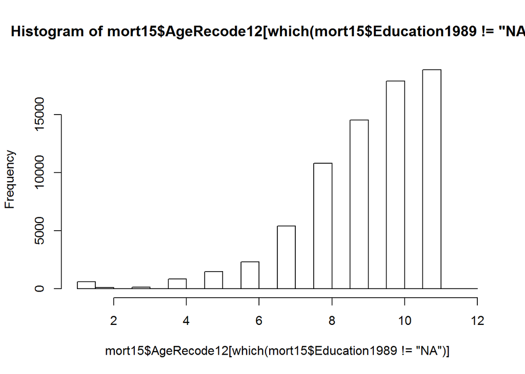

```r
hist(mort15$AgeRecode12[which(mort15$Education1989 != "NA")])#It is used overwhelmingly for older persons
```

```r
which(mort15$Education2003[which(mort15$Education1989 != "NA")] != "NA") ##It is recorded for all and only those records for which there
```

```
## integer(0)
```

```r
##Is no Education2003, at 2.7% of the dataset. We should be able to purge these records and delete the column
mort15 <- mort15[-which(mort15$Education1989 != "NA"),]
mort15$Education1989 <- NULL

mort15$EducationFlag <- NULL #This column marks whether Education1989 was used or not.
mort15[,6:9] <- NULL #These columns are recodes of age into various buckets. These are easy to replace later should we choose to do so.

mort15 <- mort15[-which(mort15$Education == 9),] #9 indicates unknown education. We'll be looking a lot at education later so it's best to prune

#write.csv(mort15, "Mortality15Cleaned.CSV") #Since this takes so long to load we should back up regularly
#mort15 <- read.csv("Mortality15Cleaned.CSV")
#mort15[,1] <- NULL
```

# Prepping Cause of Death

For this analysis we’ll be looking a lot at causes of death. These are recorded in the X27 variable, which is over 200 characters long and has 2*20 entries for cause of death and contributing causes of death. One group is Entity-Axis records, the other is Row-Axis, a lightly processed EAC which removes errors, contradictions, and sorts alphabetically all contributing causes of death listed on a patient’s death certificate. Since this is such a cumbersome part of the dataset we’ll load it into its own data frame.

```r
#install.packages("tidyr")
library(tidyr) #We're using the separate function in tidyr
mort15cod <- NULL
mort15cod = separate(data=mort15, col=X27, into=
                   c("neac","eac1","eac2","eac3","eac4","eac5","eac6","eac7","eac8","eac9",
                     "eac10","eac11","eac12","eac13","eac14","eac15","eac16","eac17","eac18","eac19","eac20","blank",
                     "nrac","rac1","rac2","rac3","rac4","rac5","rac6","rac7","rac8","rac9","rac10",
                     "rac11","rac12","rac13","rac14","rac15","rac16","rac17","rac18","rac19","rac20"),
                 sep=c(3,7*seq(from=1, to=20)+3,146,182,5*seq(from=1, to=20)+182))[,c(42:62,71)]
```

We’ll just be using RAC in this case, since 39 dimensions is a lot. We also have the number of conditions listed as nrac. rac1 is equal to icd10 from the original data frame - the principal cause of death. We also need to keep track of our indicies if we’re splitting the data off into a second matrix.

```r
mort15cod$nrac <- as.numeric(mort15cod$nrac)

mort15cod[,2:21] <- apply(mort15cod[,2:21],2,trimws) ##We'll also trim the white space while we're at it to keep everything nice and neat.

str(mort15cod) #Looking good so far
```

```
## 'data.frame':    2525312 obs. of  22 variables:
##  $ nrac : num  2 7 1 5 3 4 1 1 2 4 ...
##  $ rac1 : chr  "I500" "C349" "G309" "X91" ...
##  $ rac2 : chr  "L031" "F179" "" "S223" ...
##  $ rac3 : chr  "" "I251" "" "S299" ...
##  $ rac4 : chr  "" "I469" "" "T149" ...
##  $ rac5 : chr  "" "J440" "" "T71" ...
##  $ rac6 : chr  "" "J90" "" "" ...
##  $ rac7 : chr  "" "R042" "" "" ...
##  $ rac8 : chr  "" "" "" "" ...
##  $ rac9 : chr  "" "" "" "" ...
##  $ rac10: chr  "" "" "" "" ...
##  $ rac11: chr  "" "" "" "" ...
##  $ rac12: chr  "" "" "" "" ...
##  $ rac13: chr  "" "" "" "" ...
##  $ rac14: chr  "" "" "" "" ...
##  $ rac15: chr  "" "" "" "" ...
##  $ rac16: chr  "" "" "" "" ...
##  $ rac17: chr  "" "" "" "" ...
##  $ rac18: chr  "" "" "" "" ...
##  $ rac19: chr  "" "" "" "" ...
##  $ rac20: chr  "" "" "" "" ...
##  $ V44  : int  1 2 3 4 5 6 7 8 9 11 ...
```

The clustering techniques we’ll be using on this matrix scale very poorly with size, so it would be prudent to eliminate some variables. Records which list a very large number of conditions account for a very small percentage of the dataset so it shouldn’t hurt to much to prune them. We can check how many people have a number of conditions >X and remove records which correspond to a very small % of the dataset, say <5%.

```r
length(which(mort15cod[,9]!=""))/length(mort15cod$nrac)  ## Only 2.2% of records have 8 or more conditions listed.
```

```
## [1] 0.02264552
```

```r
mort15cod <- mort15cod[-which(mort15cod[,9]!=""),] ##Purge the records
mort15cod[,9:21]<-NULL ##Drop the columns
str(mort15cod) ##We can turn this resulting matrix into a categorical matrix for analysis.
```

```
## 'data.frame':    2468125 obs. of  9 variables:
##  $ nrac: num  2 7 1 5 3 4 1 1 2 4 ...
##  $ rac1: chr  "I500" "C349" "G309" "X91" ...
##  $ rac2: chr  "L031" "F179" "" "S223" ...
##  $ rac3: chr  "" "I251" "" "S299" ...
##  $ rac4: chr  "" "I469" "" "T149" ...
##  $ rac5: chr  "" "J440" "" "T71" ...
##  $ rac6: chr  "" "J90" "" "" ...
##  $ rac7: chr  "" "R042" "" "" ...
##  $ V44 : int  1 2 3 4 5 6 7 8 9 11 ...
```

```r
#mort15cod[,2:8] <- apply(mort15cod[,2:8],2,as.factor) ##Why doesn't Apply work with as.factor?


h<- c(unique(unlist(apply(mort15cod[,2:8],2,unique)))) #Since COD and RAC are drawn from the same list we might want to keep the levels of every
#column the same.

#h[3698] #I ran into some trouble keeping "" as a factor before

mort15cod[,2]<-factor(mort15cod[,2],levels=h)
mort15cod[,3]<-factor(mort15cod[,3],levels=h)
mort15cod[,4]<-factor(mort15cod[,4],levels=h)
mort15cod[,5]<-factor(mort15cod[,5],levels=h)
mort15cod[,6]<-factor(mort15cod[,6],levels=h)
mort15cod[,7]<-factor(mort15cod[,7],levels=h)
mort15cod[,8]<-factor(mort15cod[,8],levels=h)

str(mort15cod)
```

```
## 'data.frame':    2468125 obs. of  9 variables:
##  $ nrac: num  2 7 1 5 3 4 1 1 2 4 ...
##  $ rac1: Factor w/ 5347 levels "I500","C349",..: 1 2 3 4 5 6 7 1 8 9 ...
##  $ rac2: Factor w/ 5347 levels "I500","C349",..: 128 296 3698 3699 3700 261 3698 3698 1 42 ...
##  $ rac3: Factor w/ 5347 levels "I500","C349",..: 3698 64 3698 3750 99 296 3698 3698 3698 16 ...
##  $ rac4: Factor w/ 5347 levels "I500","C349",..: 3698 41 3698 3754 3698 104 3698 3698 3698 138 ...
##  $ rac5: Factor w/ 5347 levels "I500","C349",..: 3698 149 3698 3702 3698 3698 3698 3698 3698 3698 ...
##  $ rac6: Factor w/ 5347 levels "I500","C349",..: 3698 235 3698 3698 3698 3698 3698 3698 3698 3698 ...
##  $ rac7: Factor w/ 5347 levels "I500","C349",..: 3698 2362 3698 3698 3698 3698 3698 3698 3698 3698 ...
##  $ V44 : int  1 2 3 4 5 6 7 8 9 11 ...
```

```r
#To keep things consistent we'll prune the same records in our original dataset.
mort15 <- mort15[which(mort15$V44 %in% mort15cod$V44),]

h<-NULL #To save memory we can clean up dummy variables after.

#write.csv(mort15, "Mortality15CODPurge.csv")
#write.csv(mort15cod, "MortalityCODInitial.csv")

#mort15 <- read.csv("Mortality15CODPurge.csv")
#mort15cod <- read.csv("MortalityCODInitial.csv")
#mort15[,1] <- NULL
#mort15cod[,1] <- NULL
#Keeping backups is important, these things take a long time to reload if you mess up.
```

# Cleaning Continued

Looking back towards the main dataset we can look at some more bits of cleaning to do. To start, my own interest in this project is to look at persons 18 years of age or older, since childhood diseases are a whole field of study on their own. Additionally age recode variables can be gotten rid of for now, since they’re quite easy to replace. Other recode variables like race or cause of death are not as easily replaced as age recodes, and additionally we may want to take a closer look at these with clustering analyses.

```r
mort15 <- mort15[which(mort15$AgeDetail > 1017 & mort15$AgeDetail < 1999),]
mort15$AgeDetail <- (mort15$AgeDetail -1000) #The ages are stored with the first digit denoting Years/Months/Minutes of life. 1### is years, we don't need the others.
mort15$CauseRecode130 <- NULL #Recode 130 is specifically for infant mortalities
mort15$RaceRecord5 <- as.factor(mort15$RaceRecord5) #We'll also be needing this
```

Finally we can look at deaths not directly related to health, such as accidental deaths. Initially these may seem to be not all that relevant to what I’ve mentioned so far, but I have heard from my father, a psychiatrist, that accidental deaths correlate pretty strongly with suicides, and I’d like to test that hypothesis.

This means things like homicide, car accidents, and warfare are our candidates for removal. Non-health related deaths can be found by looking in the documentation. The upper registers of CauseRecode358 include all non-disease related deaths including homicide, accidental poisoning, and so on, from bin no. 384 and up. These entries will be moved to another dataset, mort15accidental.

The groups 384 and up can be thought of roughly as:

456 - 453 Medical Malpractise 452 - 449 Law Enforement / Soldiering 448 - 442 Unknown Intent death guns/poison 441 - 432 Assault and Homicide 431 - 424 Suicide Self Harm 423 - 419 Accidental Poisoning 418 - 416 Acts of Nature 415 - 407 Accidental / Building Hazard / Choking hazard 406 - 403 Falling 402 - 381 Vehicular Accidents 390 - 384 Car Driving 399 Unspecified 400 Boating

The variable MannerofDeath also includes lists of deaths deemed accidental or unknown in cause. We’ll shove aside the inclusion of both groups into mort15accidental.

1 … Accident 2 … Suicide 3 … Homicide 4 … Pending investigation 5 … Could not determine 6 … Self-Inflicted 7 … Natural - This is what we want to focus on. Blank … Not specified - Why this is an option I cannot say

```r
mort15accidental <- mort15[-which(mort15$CauseRecode358 < 384),]
#These are all the self-harm and accidental, ie non-medical deaths
#We won't include them in our primary analysis, but we will look at them later to compare some results.



mort15 <- mort15[which(mort15$CauseRecode358 < 384),]
table(mort15accidental$MannerOfDeath)
```

```
##
##      1      2      3      4      5      7
## 114895  40136  16002    230   4259  11293
```

```r
#Even though CauseRecode defines these as more accidental deaths, many are listed as natural. The documentation is very unclear about this.
table(mort15$MannerOfDeath)
```

```
##
##       1       2       3       4       5       7
##    9180      76     122    2807    3002 1872639
```

```r
#The overwhelming of records left over are from natural causes. Curiously many of the records have this value left blank. Since we already
#removed CauseRecode358's accidental deaths we could probably assume that the blank records left are natural deaths, but we can double check by
#tabling with respect to some other cause of death binning.

length(mort15$MannerOfDeath) - sum(table(mort15$MannerOfDeath))
```

```
## [1] 358457
```

```r
length(mort15$CauseRecode113[which(is.na(mort15$MannerOfDeath))]) #These should be the same.
```

```
## [1] 358457
```

```r
sort(table(mort15$CauseRecode113[which(is.na(mort15$MannerOfDeath))]),decreasing=T)[1:5]
```

```
##
##   111    63    70    27    52
## 39709 29264 22404 21334 20512
```

```r
#What are the top 5 causes of death among those who have no manner of death listed?
#From the documentation they are: Misc. Disease, Chronic Heart Disease, Cerebrovascular Disease, Lung Cancer, and Alzheimers
#It should be safe to include the NAs in our disease analysis.

length(which(mort15$MannerOfDeath %in% c(1:6)))
```

```
## [1] 15187
```

```r
sum(table(mort15$MannerOfDeath)[1:5]) #These should be the same. It's Table[1:5] because 6 is self-harm which had been wiped with cause recodes.
```

```
## [1] 15187
```

```r
mort15accidental <- rbind.data.frame(mort15accidental, mort15[which(mort15$MannerOfDeath %in% c(1:6)),])
mort15 <- mort15[-which(mort15$MannerOfDeath %in% c(1:6)),]

mort15cod <- mort15cod[which(mort15cod$V44 %in% mort15$V44),]
#write.csv(mort15accidental, "mort15accidental.csv")
#write.csv(mort15, "mort15pacc.csv")
#write.csv(mort15cod, "mort15codpacc.csv")
#mort15<- read.csv("mort15pacc.csv")
#mort15[,1] <-NULL
```

With these row exclusions out of the way we can start looking at some more in depth analysis.

# Data Analysis §1

The first step in a good analysis is to get a better understanding of the data and the trends in it. Let’s start by making a few visualizations, and asking some basic questions. Some questions we might ask are…

1. When do people die?
2. How old are people when they die?
3. What are the differences between men and women?
4. What are the most common means of death?
5. How do various factors influence Age of Death Re:gression
6. What is the distribution of these variables? - Normal? Skew? Flat?

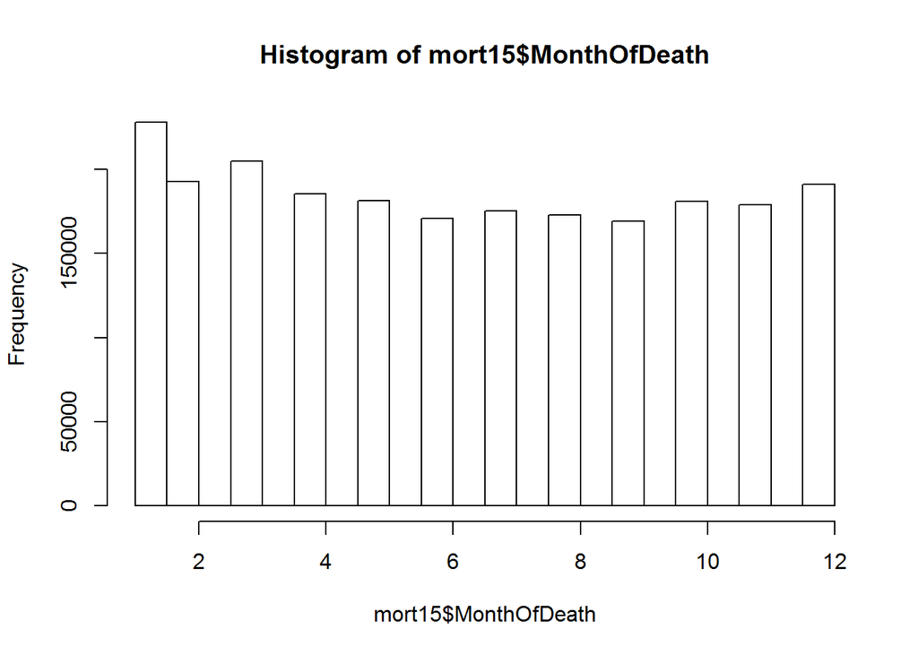

```r
hist(mort15$MonthOfDeath)
```

As expected the colder months are not kind to the infirm.

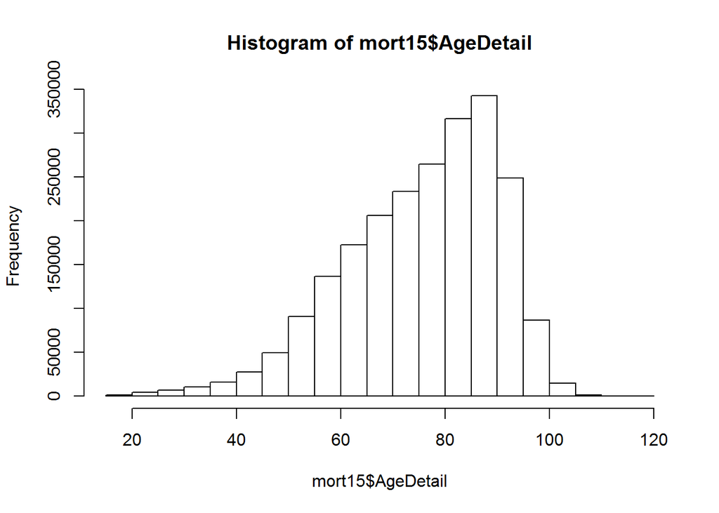

```r
hist(mort15$AgeDetail, breaks=20)
```

```r
median(mort15$AgeDetail)
```

```
## [1] 79
```

```r
mean(mort15$AgeDetail)
```

```
## [1] 76.11624
```

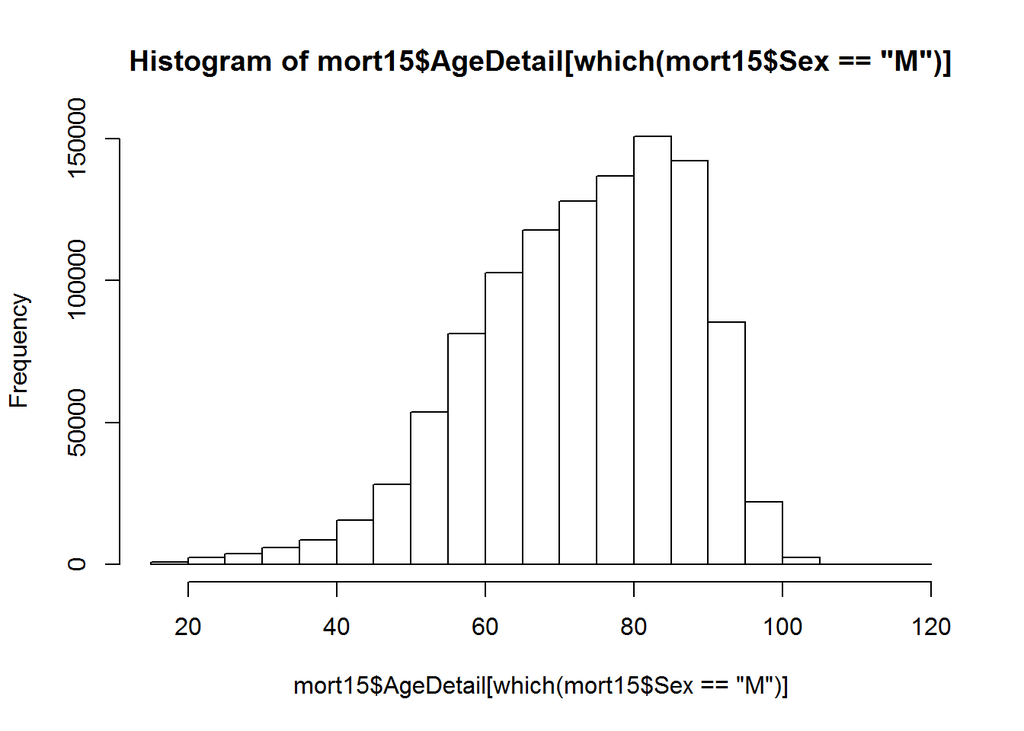

```r
hist(mort15$AgeDetail[which(mort15$Sex =='M')], breaks=20)
```

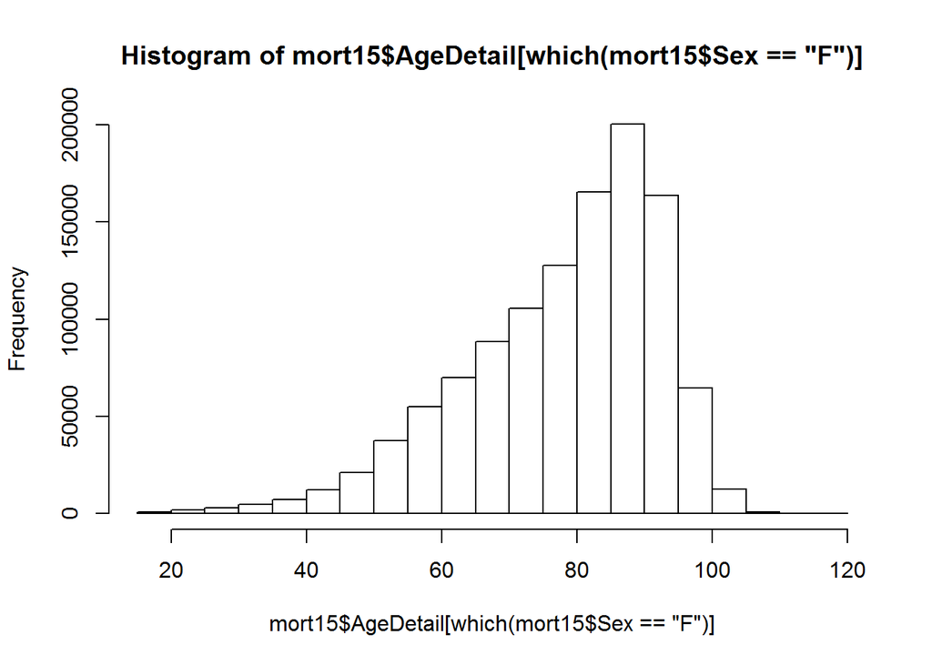

```r
hist(mort15$AgeDetail[which(mort15$Sex =='F')], breaks=20)
```

```r
median(mort15$AgeDetail[which(mort15$Sex =='M')])
```

```
## [1] 75
```

```r
median(mort15$AgeDetail[which(mort15$Sex =='F')])
```

```
## [1] 82
```

As one often hears, women live longer than men with 82 and 75 being the respective median ages of death.

What are some of the leading and least common causes of death? We’ll look at the CauseRecode113 as opposed to ICD10 for a more general picture.

```r
sort(table(mort15$CauseRecode113))
```

```
##
##      7      8     13      2     17    106    108    101      9     81
##      1      2      2      3     11     17     21     23     29     29
##     11      1     42    104      6     80     49     99      5     91
##     40     42     84    104    121    181    183    256    288    308
##     50     98    103     83     87    102     66     38    107     65
##    428    437    477    511    598    619    763   1027   1042   1191
##     92     90     55     85     96     26    109     60     30     75
##   1796   2690   2935   3001   3260   3408   3762   3779   3853   3923
##     48     57     45     77     71     18     16     84     15     28
##   4436   4485   4594   4735   5560   5615   5759   6430   6616   8290
##     74      3     20     73     31     22     41     32     34     21
##   8517   8536   8953   9022   9436  10514  11747  12946  13376  13980
##     36     44     35     95     88     39     94     40    110     24
##  14737  14834  14876  17289  17551  18657  19157  20467  21901  23706
##     51     33     69     89     10     56     25     29    100     78
##  25891  26729  29393  34174  35459  37694  38758  38985  44919  46775
##     23     62     43     67     46     59     52     68     70     86
##  48981  53581  63117  68541  71694 103211 103276 123822 128036 129062
##     27     63    111
## 140709 167795 282527
```

Recodes 111, 63, 27, 86, and 70 are the most common methods of death 7, 8, 13, 2, and 17 the least common.

From the literature we find out that these are… Top: Misc. Disease, Chronic Ischemic Heart Disease, Lung/Trachea/Bronchus Neoplasms ie cancer, Chronic Lung Disease, and Cerebrovascular Disease (including Arterio-venus malformations? Don’t google this). Bottom: Whooping Cough, Scarlet Fever, Encephalitis, Amoeba Infection, and Malaria.

How do some of the variables influence age of death?

```r
str(mort15)
```

```
## 'data.frame':    2231096 obs. of  27 variables:
##  $ ResidentStatus      : int  1 1 1 1 1 1 1 1 1 1 ...
##  $ Education2003       : int  3 6 3 5 6 4 3 3 6 3 ...
##  $ MonthOfDeath        : int  1 1 1 1 1 1 1 1 1 1 ...
##  $ Sex                 : Factor w/ 2 levels "F","M": 2 2 1 1 2 2 2 1 1 1 ...
##  $ AgeDetail           : num  84 70 91 89 78 92 82 89 84 84 ...
##  $ PlaceOfDeath        : int  1 1 4 6 4 4 4 4 6 6 ...
##  $ MaritalStatus       : Factor w/ 5 levels "D","M","S","U",..: 2 2 5 5 5 5 2 5 2 2 ...
##  $ DayOfWeekofDeath    : int  1 2 6 5 6 1 1 1 1 1 ...
##  $ InjuryAtWork        : Factor w/ 3 levels "N","U","Y": 2 2 2 2 2 2 2 2 2 2 ...
##  $ MannerOfDeath       : int  7 7 7 7 7 7 7 7 7 7 ...
##  $ MethodOfDisposition : Factor w/ 7 levels "B","C","D","E",..: 1 2 2 2 2 6 2 1 1 2 ...
##  $ Autopsy             : Factor w/ 3 levels "N","U","Y": 1 1 1 1 1 1 1 1 1 1 ...
##  $ ActivityCode        : int  NA NA NA NA NA NA NA NA NA NA ...
##  $ PlaceOfInjury       : int  NA NA NA 9 NA NA NA NA NA NA ...
##  $ ICDCode             : Factor w/ 3783 levels "A009","A014",..: 1567 390 1267 1478 1576 976 1567 1513 1560 1267 ...
##  $ CauseRecode358      : int  230 93 189 214 233 161 230 225 228 189 ...
##  $ CauseRecode113      : int  67 27 52 62 68 111 67 68 68 52 ...
##  $ CauseRecode39       : int  22 8 17 21 22 37 22 22 22 17 ...
##  $ X27                 : Factor w/ 1155782 levels " 0111A021                                                                                                                      "| __truncated__,..: 37750 1087758 798 150786 472578 639 976 37238 512870 25604 ...
##  $ Race                : int  1 1 1 1 3 1 1 1 1 1 ...
##  $ BridgeRaceFlag      : int  NA NA NA NA NA NA NA NA NA NA ...
##  $ RaceImputationFlag  : int  NA NA NA NA NA NA NA NA NA NA ...
##  $ RaceRecode3         : int  1 1 1 1 2 1 1 1 1 1 ...
##  $ RaceRecord5         : Factor w/ 4 levels "1","2","3","4": 1 1 1 1 3 1 1 1 1 1 ...
##  $ HispanicOrigin      : int  100 100 100 100 100 100 100 100 100 100 ...
##  $ HispanicOriginRecode: int  6 6 6 6 8 6 6 6 6 6 ...
##  $ V44                 : int  1 2 3 5 6 7 8 9 11 12 ...
```

```r
mortreg <- glm(AgeDetail ~ Education2003 + Sex + RaceRecord5 + MethodOfDisposition + MaritalStatus, data=mort15)
summary(mortreg)
```

```
##
## Call:
## glm(formula = AgeDetail ~ Education2003 + Sex + RaceRecord5 +
##     MethodOfDisposition + MaritalStatus, data = mort15)
##
## Deviance Residuals:
##     Min       1Q   Median       3Q      Max
## -65.862   -7.193    1.130    8.118   48.480
##
## Coefficients:
##                       Estimate Std. Error  t value Pr(>|t|)
## (Intercept)          72.503978   0.030171 2403.082  < 2e-16 ***
## Education2003         0.089822   0.004974   18.058  < 2e-16 ***
## SexM                 -0.510315   0.017294  -29.508  < 2e-16 ***
## RaceRecord52         -4.982300   0.026122 -190.729  < 2e-16 ***
## RaceRecord53         -7.230774   0.101454  -71.271  < 2e-16 ***
## RaceRecord54         -1.479289   0.051299  -28.837  < 2e-16 ***
## MethodOfDispositionC -3.191681   0.017213 -185.427  < 2e-16 ***
## MethodOfDispositionD -0.538191   0.077846   -6.914 4.73e-12 ***
## MethodOfDispositionE  2.859870   0.065302   43.794  < 2e-16 ***
## MethodOfDispositionO  0.295479   0.132168    2.236   0.0254 *
## MethodOfDispositionR -1.908450   0.050480  -37.806  < 2e-16 ***
## MethodOfDispositionU -3.669466   0.589642   -6.223 4.87e-10 ***
## MaritalStatusM        2.709141   0.024730  109.551  < 2e-16 ***
## MaritalStatusS       -6.899867   0.033515 -205.876  < 2e-16 ***
## MaritalStatusU       -1.631094   0.158118  -10.316  < 2e-16 ***
## MaritalStatusW       14.599347   0.025338  576.185  < 2e-16 ***
## ---
## Signif. codes:  0 '***' 0.001 '**' 0.01 '*' 0.05 '.' 0.1 ' ' 1
##
## (Dispersion parameter for gaussian family taken to be 145.959)
##
##     Null deviance: 469297517  on 2231095  degrees of freedom
## Residual deviance: 325646145  on 2231080  degrees of freedom
## AIC: 17449872
##
## Number of Fisher Scoring iterations: 2
```

Doing a multiple linear regression on some choice variables reveals some interesting, and perhaps counterintuitive trends. Going down the list:

Education - Scales positively, but quite poorly. This could be because higher education is overrepresented in younger people, since the demand for PhDs has gone up only over the past few decades.

```r
edureg <- lm(AgeDetail ~ Education2003, data=mort15)
summary(edureg)
```

```
##
## Call:
## lm(formula = AgeDetail ~ Education2003, data = mort15)
##
## Residuals:
##     Min      1Q  Median      3Q     Max
## -59.069  -9.307   2.693  11.312  40.837
##
## Coefficients:
##               Estimate Std. Error t value Pr(>|t|)
## (Intercept)   77.44991    0.02265 3418.82   <2e-16 ***
## Education2003 -0.38108    0.00585  -65.15   <2e-16 ***
## ---
## Signif. codes:  0 '***' 0.001 '**' 0.01 '*' 0.05 '.' 0.1 ' ' 1
##
## Residual standard error: 14.49 on 2231094 degrees of freedom
## Multiple R-squared:  0.001899,   Adjusted R-squared:  0.001898
## F-statistic:  4244 on 1 and 2231094 DF,  p-value: < 2.2e-16
```

A look at Age v Education alone supports this hypothesis, with education actually being negatively correlated with age of death.

Sex - As we saw before women live longer on average

Race - With 1 being white, it is no surprise that in America all others do worse.

Method of Dispotition - Burial, Cremation, Donation, Entombment, Removal from State, Unknown, and Other are the available choices. With the high cost of burials and crypts it is no surprise that those who can afford them will live longer.

Marital Status - Married persons live longer, and Widows by far and away live longer. This could be because women, who live longer, are oversampled in the class of widows, and because widows were by definition married at some point.

```r
table(mort15$Sex[which(mort15$MaritalStatus == "W")])
```

```
##
##      F      M
## 594491 216729
```

As the results show this theory seems pretty sound.

```r
edureg <- NULL
mortreg <- NULL
```

# Data Analysis §2

Now that we’ve gotten a look see at some of the trends let’s do some more in depth analysis and computation

One critical factor for determining life expectancy is wealth, which is not listed in this dataset.

# Question 1:

Can we infer wealth information from other variables? The motivation here could be dimensionality reduction - imagine the computational speedup if this were very very big data. Or consider a situation where we didn’t know if our variables had any underlying factors.

Which variables can we infer wealth from? Some familiar candidates come to mind:

Race - Unfortunately still a solid predictor of social status.

Education - More education leads to higher paying jobs.

Method of Dispostition - Burials are expensive. In 2014 the mean burial price was >$7000, per the mortician’s association of USA. http://fortune.com/2015/10/30/cremation-death-funeral/

Marital Status - Married persons are on average wealthier.

Age: Richer people can afford to live longer

Principle Component Analysis (PCA) is usually used to tackle this kind of problem, but it alone won’t do the trick here, since it is based on techniques of analysis for numerical data. Our data is more categorical, requiring a different approach with a different distance metric. What are some methods of PCA for mixed data types? FactoMineR has Factor Analysis of Mixed Data (FADM) for Exploratory Data Analysis.

FADM is a combination of Correspondence Analysis for categorical variables, and PCA for numeric variables, which could work better here. However, there are still some assumptions of PCA to consider. For instance, at least for ordinal or interval variables there is an assumption of normality. It would help to deal with our age variable in some way, since it’s skewed. One technique would be to transform it, another to bin it. We’ll try a couple of approaches and see what works.

```r
#install.packages("FactoMineR")
library(FactoMineR)
str(mort15[,c(2,5,7,11,24)])
```

```
## 'data.frame':    2231096 obs. of  5 variables:
##  $ Education2003      : int  3 6 3 5 6 4 3 3 6 3 ...
##  $ AgeDetail          : num  84 70 91 89 78 92 82 89 84 84 ...
##  $ MaritalStatus      : Factor w/ 5 levels "D","M","S","U",..: 2 2 5 5 5 5 2 5 2 2 ...
##  $ MethodOfDisposition: Factor w/ 7 levels "B","C","D","E",..: 1 2 2 2 2 6 2 1 1 2 ...
##  $ RaceRecord5        : Factor w/ 4 levels "1","2","3","4": 1 1 1 1 3 1 1 1 1 1 ...
```

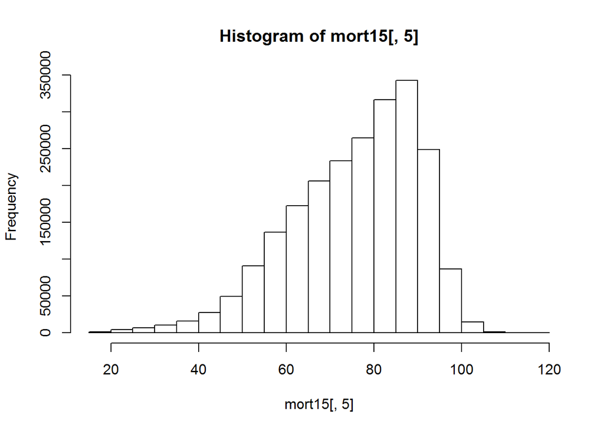

```r
#mort15[,24] <-as.factor(mort15[,24])
hist(mort15[,5])#Not so normal
```

```r
levels(mort15[,24]) <-  c("w","b","n","p")
#mort15[,24]
#Having too many variables with the same values would be confusing.
str(mort15[,c(2,5,7,11,24)])
```

```
## 'data.frame':    2231096 obs. of  5 variables:
##  $ Education2003      : int  3 6 3 5 6 4 3 3 6 3 ...
##  $ AgeDetail          : num  84 70 91 89 78 92 82 89 84 84 ...
##  $ MaritalStatus      : Factor w/ 5 levels "D","M","S","U",..: 2 2 5 5 5 5 2 5 2 2 ...
##  $ MethodOfDisposition: Factor w/ 7 levels "B","C","D","E",..: 1 2 2 2 2 6 2 1 1 2 ...
##  $ RaceRecord5        : Factor w/ 4 levels "w","b","n","p": 1 1 1 1 3 1 1 1 1 1 ...
```

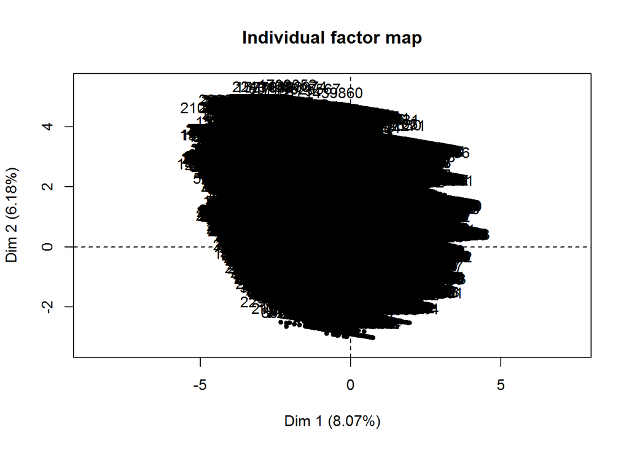

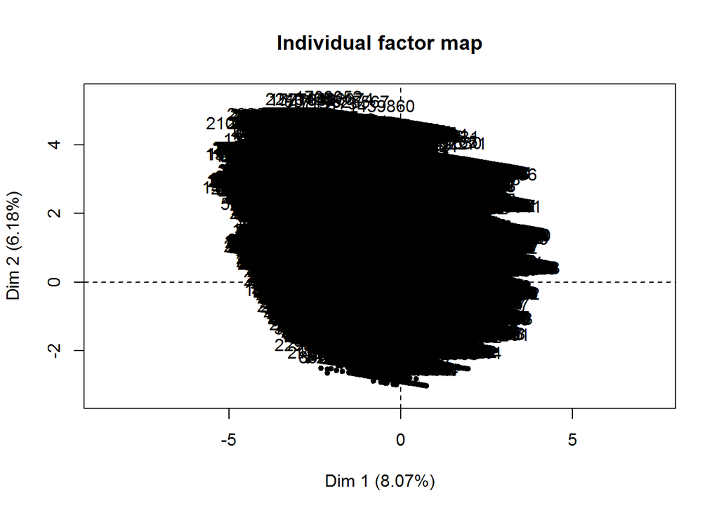

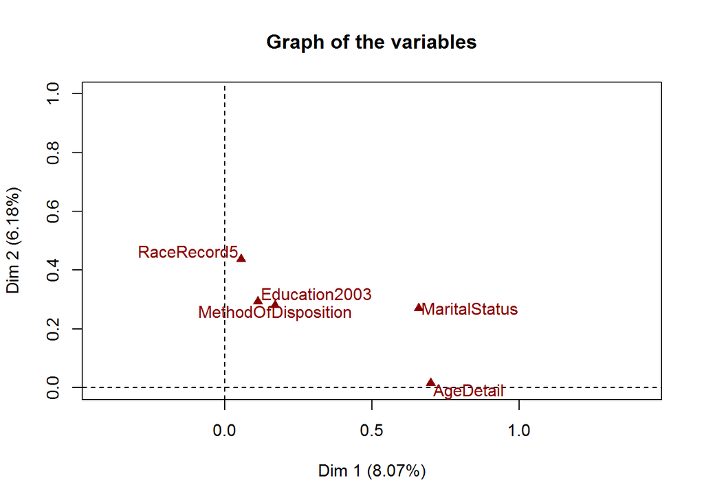

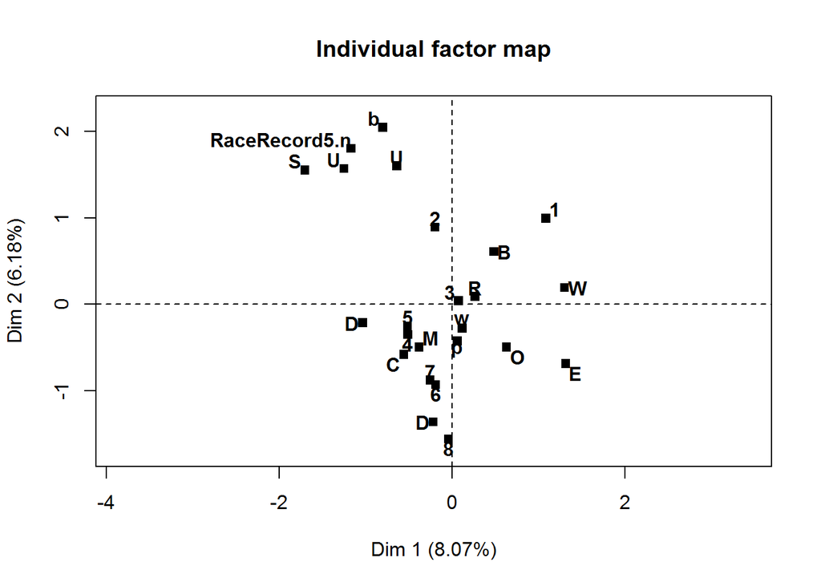

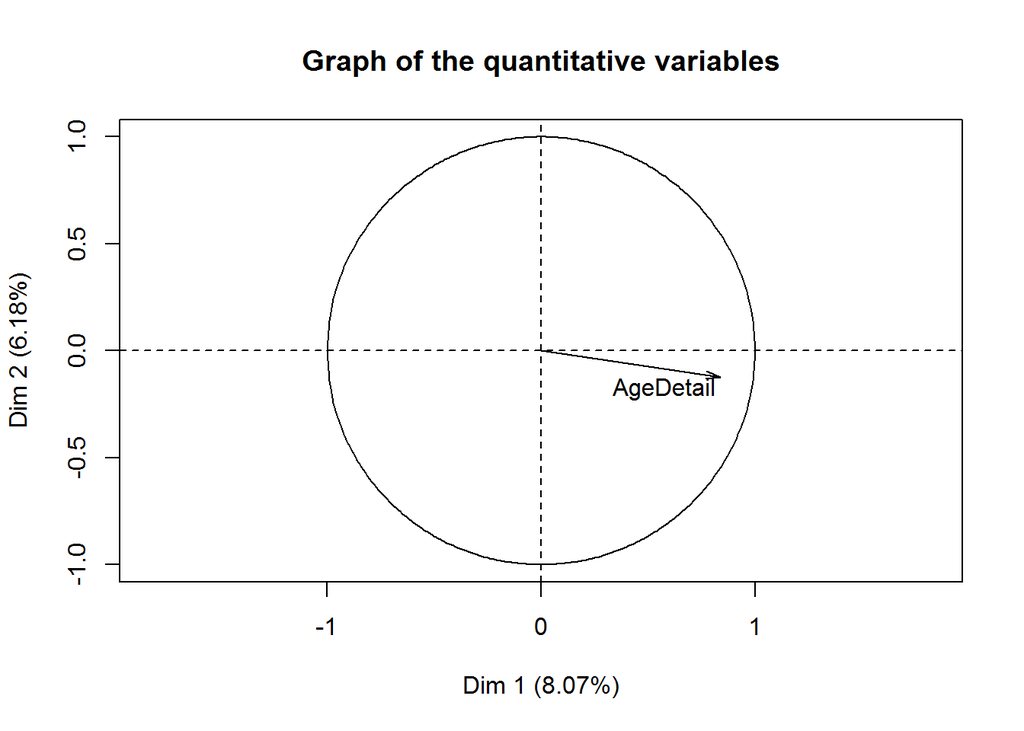

```r
#Since Education's binning is non-normal and not really ordinal, and since there're a small number of levels we'll treat it as a factor
mort15[,2] <- as.factor(mort15[,2])


mort15famd <- FAMD(mort15[,c(2,5,7,11,24)], ncp=10, graph=T)
```

```r
summary(mort15famd)
```

```
##
## Call:
## FAMD(base = mort15[, c(2, 5, 7, 11, 24)], ncp = 10, graph = T)
##
##
## Eigenvalues
##                       Dim.1  Dim.2  Dim.3  Dim.4  Dim.5  Dim.6  Dim.7
## Variance              1.695  1.298  1.122  1.021  1.018  1.016  1.010
## % of var.             8.074  6.179  5.345  4.860  4.849  4.836  4.812
## Cumulative % of var.  8.074 14.253 19.598 24.458 29.307 34.142 38.954
##                       Dim.8  Dim.9 Dim.10
## Variance              1.005  1.004  0.999
## % of var.             4.788  4.782  4.756
## Cumulative % of var. 43.741 48.523 53.279
##
## Individuals (the 10 first)
##                         Dist    Dim.1    ctr   cos2    Dim.2    ctr   cos2
## 1                   |  2.116 |  0.519  0.000  0.060 | -0.148  0.000  0.005
## 2                   |  3.399 | -0.872  0.000  0.066 | -1.709  0.000  0.253
## 3                   |  2.336 |  1.205  0.000  0.266 | -0.588  0.000  0.063
## 5                   |  4.372 |  0.769  0.000  0.031 | -0.798  0.000  0.033
## 6                   | 12.890 | -0.283  0.000  0.000 |  0.366  0.000  0.001
## 7                   |  6.784 |  1.389  0.000  0.042 | -0.379  0.000  0.003
## 8                   |  2.103 | -0.185  0.000  0.008 | -1.052  0.000  0.250
## 9                   |  2.262 |  1.732  0.000  0.586 |  0.345  0.000  0.023
## 11                  |  3.405 |  0.363  0.000  0.011 | -0.895  0.000  0.069
## 12                  |  2.134 | -0.096  0.000  0.002 | -1.067  0.000  0.250
##                        Dim.3    ctr   cos2
## 1                   |  0.180  0.000  0.007 |
## 2                   |  1.153  0.000  0.115 |
## 3                   | -1.046  0.000  0.201 |
## 5                   | -0.601  0.000  0.019 |
## 6                   |  0.510  0.000  0.002 |
## 7                   | -0.155  0.000  0.001 |
## 8                   | -0.207  0.000  0.010 |
## 9                   | -0.645  0.000  0.081 |
## 11                  |  1.498  0.000  0.194 |
## 12                  | -0.214  0.000  0.010 |
##
## Continuous variable
```

[output cut: 24 more lines]

```
## 7                      1.953    0.034 -243.030 |    0.864    2.536
## 8                      2.580    0.044 -275.762 |    1.944    5.371
## D                      0.414    0.008 -119.127 |   -1.223   18.407
## M                      5.571    0.145 -511.581 |    0.638   12.388
##                         cos2   v.test
## 1                      0.087  423.784 |
## 2                      0.015 -172.910 |
## 3                      0.189 -613.947 |
## 4                      0.002  -64.046 |
## 5                      0.000   -3.190 |
## 6                      0.112  475.429 |
## 7                      0.033  257.565 |
## 8                      0.068  370.077 |
## D                      0.259 -738.607 |
## M                      0.241  709.462 |
```

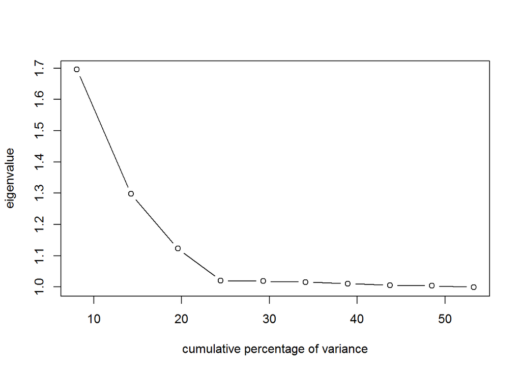

```r
plot(mort15famd$eig[c(3,1)], type = "b")
```

The results of a factor analysis are tricky to interperet, but the leftward skew of the graph, and relative flatness by component four indicates some correlation among the variables (we started out with five). However this is countered by the low amount of variance explained by each variable - though this could be due to noise. On the individual factor map you can see 1, W, E, and B all grouped together in the right most quadrant. Remember from our multiple linear regression these were all signs of longevity. There is a general mild downward right slope.

Age Detail also points to the right. The numbers near the middle are probably education, since the effect was nowhere near as strong as race. This is only a low dimensional plot of the first two variables, but they do have the highest variance.

There exist fancier tests of model soundness in some of the literature on PCA and MCA, but they were beyond my meager abilities.

We tried FAMD with four categorical variables and one relatively skewed numeric variable. Next let’s try transforming age into a (relatively) normal shape with binning and see if we can’t get some clearer results. Ideally we could use some kind of oblique transforms on the numerical attribute to preserve its characteristic a bit better, but again these were a bit beyond my skills.

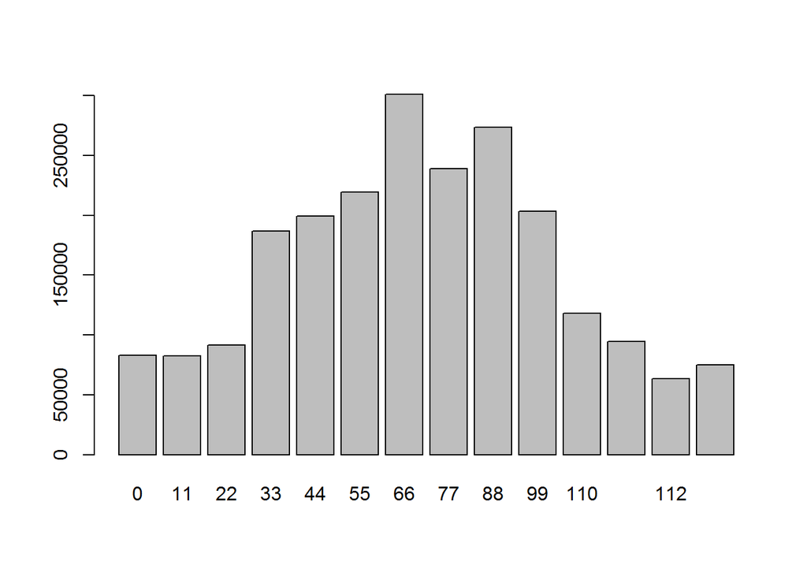

```r
normquantage <- quantile(mort15[,5], c(0.036,0.067,0.115,0.184,0.274,0.382,0.5,0.618,0.726,0.816,0.885,0.933,0.964))
#we can use the quantile function to get cutoff ages for a more normal distribution. I looked up percentiles for zscores at 0.3 increments.


mort15[,28] <- cut(mort15[,5], breaks=c(0,normquantage, Inf), labels=c(00,11,22,33,44,55,66,77,88,99,110,111,112,113))
plot(mort15[,28]) #Much more normal.
```

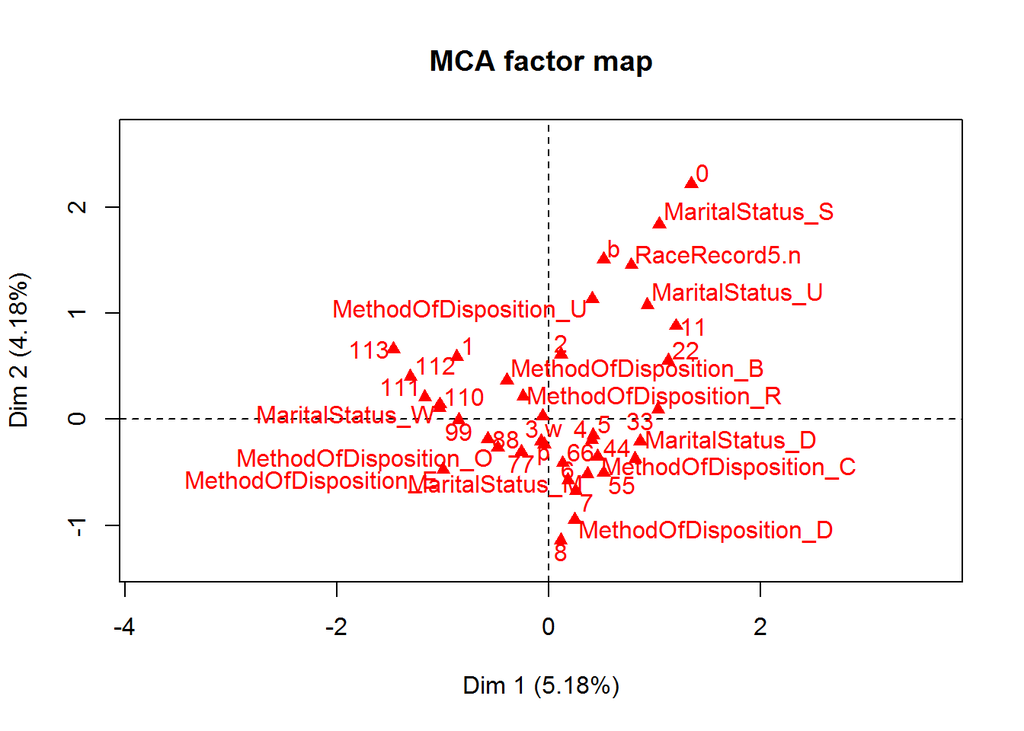

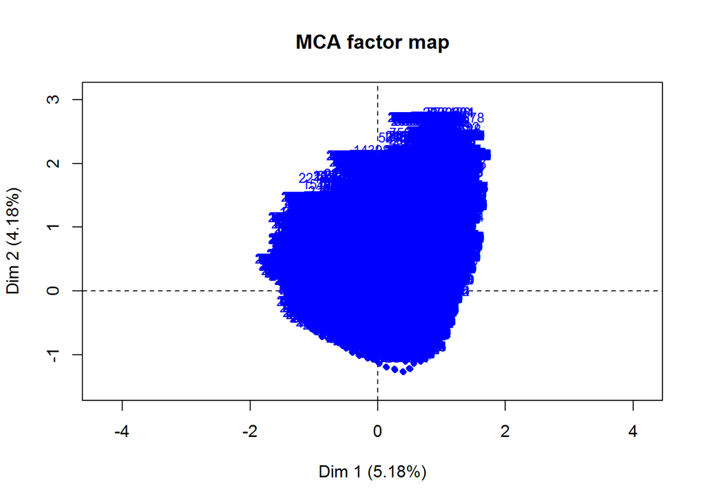

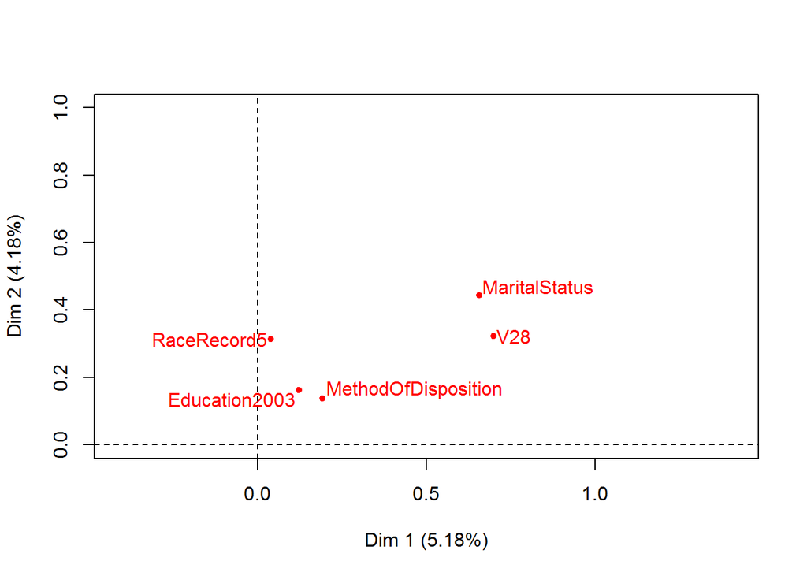

```r
mort15famd <- MCA(mort15[,c(2,7,11,24,28)], ncp=10, graph=T)
```

```r
#We're calling the FAMD function again, but under the hood it just runs MCA on factors.
summary(mort15famd)
```

```
##
## Call:
## MCA(X = mort15[, c(2, 7, 11, 24, 28)], ncp = 10, graph = T)
##
##
## Eigenvalues
##                        Dim.1   Dim.2   Dim.3   Dim.4   Dim.5   Dim.6
## Variance               0.342   0.276   0.231   0.222   0.210   0.205
## % of var.              5.184   4.177   3.498   3.359   3.179   3.113
## Cumulative % of var.   5.184   9.361  12.859  16.219  19.398  22.510
##                        Dim.7   Dim.8   Dim.9  Dim.10  Dim.11  Dim.12
## Variance               0.204   0.202   0.202   0.201   0.201   0.201
## % of var.              3.086   3.065   3.054   3.047   3.045   3.040
## Cumulative % of var.  25.597  28.662  31.715  34.762  37.807  40.847
##                       Dim.13  Dim.14  Dim.15  Dim.16  Dim.17  Dim.18
## Variance               0.200   0.200   0.200   0.200   0.200   0.200
## % of var.              3.035   3.033   3.032   3.031   3.029   3.028
## Cumulative % of var.  43.882  46.915  49.947  52.978  56.007  59.035
##                       Dim.19  Dim.20  Dim.21  Dim.22  Dim.23  Dim.24
## Variance               0.200   0.200   0.199   0.199   0.198   0.198
## % of var.              3.026   3.025   3.015   3.009   3.001   2.999
## Cumulative % of var.  62.061  65.086  68.101  71.110  74.112  77.111
##                       Dim.25  Dim.26  Dim.27  Dim.28  Dim.29  Dim.30
## Variance               0.196   0.195   0.194   0.186   0.184   0.172
## % of var.              2.971   2.960   2.934   2.821   2.788   2.607
## Cumulative % of var.  80.082  83.042  85.976  88.796  91.585  94.192
##                       Dim.31  Dim.32  Dim.33
## Variance               0.155   0.140   0.089
## % of var.              2.344   2.118   1.346
## Cumulative % of var.  96.536  98.654 100.000
##
## Individuals (the 10 first)
##                    Dim.1    ctr   cos2    Dim.2    ctr   cos2    Dim.3
## 1               | -0.254  0.000  0.029 | -0.195  0.000  0.017 |  0.310
## 2               |  0.494  0.000  0.059 | -0.821  0.000  0.164 |  0.447
## 3               | -0.594  0.000  0.079 | -0.105  0.000  0.002 | -0.574
## 5               | -0.369  0.000  0.024 | -0.217  0.000  0.008 | -0.345
## 6               |  0.176  0.000  0.001 |  0.099  0.000  0.000 |  0.307
## 7               | -0.676  0.000  0.036 |  0.027  0.000  0.000 | -0.252
## 8               |  0.147  0.000  0.009 | -0.515  0.000  0.105 |  0.205
```

[output cut: 31 more lines]

```
## 4                  0.005 -107.251 |   -0.105    0.118    0.002  -58.806 |
## 5                  0.001  -57.631 |   -0.149    0.118    0.001  -56.999 |
## 6                  0.039 -296.217 |    0.696    4.443    0.057  357.808 |
## 7                  0.020 -212.247 |    0.858    2.727    0.033  270.911 |
## 8                  0.024 -230.495 |    1.616    4.050    0.048  325.905 |
## MaritalStatus_D    0.008 -131.333 |   -1.226   20.197    0.276 -784.667 |
## MaritalStatus_M    0.166 -608.573 |    0.662   14.579    0.273  780.558 |
##
## Categorical variables (eta2)
##                       Dim.1 Dim.2 Dim.3
## Education2003       | 0.123 0.163 0.233 |
## MaritalStatus       | 0.657 0.443 0.454 |
## MethodOfDisposition | 0.193 0.137 0.058 |
## RaceRecord5         | 0.039 0.313 0.182 |
## V28                 | 0.700 0.323 0.226 |
```

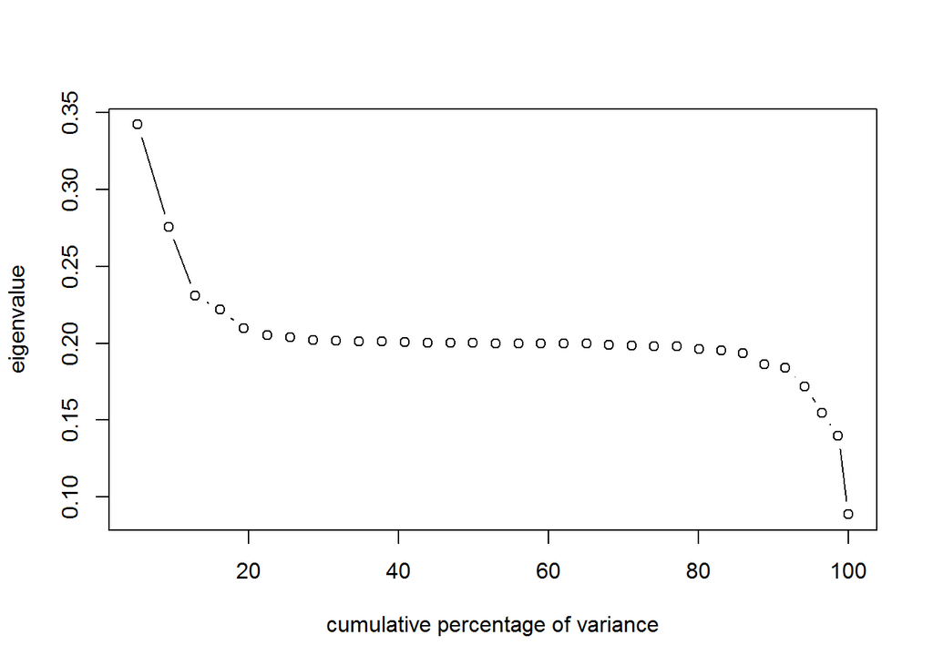

```r
plot(mort15famd$eig[c(3,1)], type = "b")
```

The overall trends are identical. The AgeDetail being on the point graph makes it a bit harder to talk about. On the whole the thing trends to the bottom left. The other interesting bit is that the cumulative variance for the first factors is smaller. This probably happened because of how we transformed the age data somewhat destructively, meaning all the data is that much noisier.

Now for another challenge. The CDC bins cause of death into various groups named CauseRecode###, and does this mainly according to where the disease is located in the body. So we get lists which go heart disease, brain disease, lung disease, and so on.

# Question 2:

Can we use machine learning techniques to look for less-expected correlations among diseases? For example I’ve heard it said that poor dental health often leads to heart disease, though in the case of this data such RACs would probably fall under headings like “infection”.

For the most part here we will be working with the X27 variable, which we loaded into its own matrix mort15cod and cleaned up. It’s a huge matrix of 5000+ causes and contributing causes of death. We’ll try to cluster over it to produce our own cause recodes, and look for anything surprising. Normally for clustering one uses kmeans, but this requires a distance metric which we don’t really have. Instead we’ll try both PAM, which uses Gower distance, and Kmodes, which looks at the modal values of our rows. Unfortunately due to the size of our matrix, and the poor scaling of these algorithms only a small sample can be clustered on my machine. With another big data tool like pyspark a more complete analysis could probably be done, but I am in R, stepped in so far…

(I also looked into something called Rock clustering, which looks for links between rows, but I don’t think it worked very well because of the sparse nature of our matrix and the way it scales with looser cluster tolerances. Mostly it just lumped everything into one cluster.)

```r
#install.packages("cluster")
#mort15cod <- mort15cod[which(mort15$V44 %in% mort15cod$V44),]
library(cluster)#For PAM
library(klaR)#For Kmodes
length(table(mort15$CauseRecode39))
```

```
## [1] 33
```

```r
#For ease of comparison we'll first try the same number of clusters as one of our recodes. We'll use the smallest one because
#It will take too long to compute if we don't.
#It's CauseRecode39, but really only 33 of them are here to begin with since we cut the data down so much.


set.seed(0) #For replicability
aa <- sample(length(mort15cod$V44),size=10000) #Much more than 10000 computes too slowly on my machine.
set.seed(0)
alpha <- kmodes(mort15cod[aa,2:8],33,iter.max=20,weighted=F)
#Iter controls the max number of clustering iterations, similar to centroids shuffling about in kmeans.
#I've looked for info on the 'weighted' parameter, but the original paper referenced in the documentation has been lost down the memory hole
#and none of the StackOverflow posts I've seen have any info. So it goes.


sort(alpha$size,decreasing=T)
```

```
## cluster
##    1    9    2    4    3   16    8    5    6   17   11   10   20   21   26
## 3442 2599  528  513  403  335  308  236  206  177  157  135  118   95   95
##   30    7   24   19   13   22   33   18   23   31   32   28   27   14   12
##   95   94   68   55   53   49   48   29   29   28   28   23   21   15   13
##   15   29   25
##    2    2    1
```

```r
sort(table(mort15$CauseRecode39[aa]),decreasing=T)
```

```
##
##   37   21   22   28   15    8   24   17   16    6   27   31    9   20   30
## 2028 1495  901  678  645  617  570  471  304  231  229  187  184  167  162
##    7   12   23   11   10   36   14   26   13    5    3   25   34   29   32
##  161  145  132  117  115   91   86   77   63   53   39   27   12    7    5
##    2
##    1
```

```r
#Right off the bat we can see a similar range of values for each cluster, so hopefully we're on the right track.
#This is probably due to the relative infrequency of high nrac rows, meaning the initial condition dominates.


cc<-mort15[aa,] # A convenient reference.

#Here we'll look at the most and least populous clusters.

ee<- trimws(unlist(names(which(sort(table(cc$ICDCode[which(as.numeric(alpha$cluster)==1)]),decreasing=T)[1:20]>0))))
  sort(table(cc$CauseRecode39[which(as.numeric(alpha$cluster)==1)]),decreasing=T)[1:20]
```

```
##
##  21  37  28   8  22  15  24  16  31  30   6  12  27  20  23  10   7  26
## 851 585 363 267 236 212 198  79  72  68  58  58  56  49  47  32  29  28
##  14  13
##  25  21
```

```r
  #ie to which cause recodes do our own clusters match most closely?
  #Another way to look at this is alphabetically. Different Letter -> Different Style of Death.
ff<- trimws(unlist(names(which(sort(table(cc$ICDCode[which(as.numeric(alpha$cluster)==9)]),decreasing=T)[1:20] > 0))))
  #sort(table(cc$ICDCode[which(as.numeric(alpha$cluster)==9)]),decreasing=T)[1:20]
gg<- trimws(unlist(names(which(sort(table(cc$ICDCode[which(as.numeric(alpha$cluster)==2)]),decreasing=T)[1:20] > 0))))
  #sort(table(cc$ICDCode[which(as.numeric(alpha$cluster)==2)]),decreasing=T)[1:20]
hh<- trimws(unlist(names(which(sort(table(cc$ICDCode[which(as.numeric(alpha$cluster)==25)]),decreasing=T)[1:20] > 0))))
  #sort(table(cc$ICDCode[which(as.numeric(alpha$cluster)==25)]),decreasing=T)[1:20]
ii<- trimws(unlist(names(which(sort(table(cc$ICDCode[which(as.numeric(alpha$cluster)==29)]),decreasing=T)[1:20] > 0))))
  #sort(table(cc$ICDCode[which(as.numeric(alpha$cluster)==29)]),decreasing=T)[1:20]
jj<- trimws(unlist(names(which(sort(table(cc$ICDCode[which(as.numeric(alpha$cluster)==15)]),decreasing=T)[1:20] > 0))))
  #sort(table(cc$ICDCode[which(as.numeric(alpha$cluster)==15)]),decreasing=T)[1:20]
```

Here we’ll finally add the icd codes from that dataset we snagged from Kaggle to make it easier to see what’s in our clusters.

```r
icd <- read.csv("Icd10Code.csv")
icd$Code <- as.character(icd$Code)
#We'll finally add the icd list from kaggle
head(icd)
```

```
##   Code                                        Description
## 1  A00                                            Cholera
## 2 A000 Cholera due to Vibrio cholerae 01, biovar cholerae
## 3 A001    Cholera due to Vibrio cholerae 01, biovar eltor
## 4 A009                               Cholera, unspecified
## 5  A01                     Typhoid and paratyphoid fevers
## 6 A010                                      Typhoid fever
```

```r
#We'll use match to return the first record of an ICD code, and see what things are listed in our groups

icd$Description[match(ee, icd$Code)]
```

```
##  [1] Atherosclerotic heart disease
##  [2] Malignant neoplasm: Bronchus or lung, unspecified
##  [3] Chronic obstructive pulmonary disease, unspecified
##  [4] Acute myocardial infarction, unspecified
##  [5] Stroke, not specified as haemorrhage or infarction
##  [6] Sepsis, unspecified
##  [7] Atherosclerotic cardiovascular disease, so described
##  [8] Pneumonia, unspecified
##  [9] Chronic obstructive pulmonary disease with acute lower respiratory infection
## [10] Malignant neoplasm: Colon, unspecified
## [11] Pneumonitis due to food and vomit
## [12] Other and unspecified cirrhosis of liver
## [13] Malignant neoplasm, without specification of site
## [14] Hypertensive heart disease without (congestive) heart failure
## [15] Atrial fibrillation and flutter
## [16] Malignant neoplasm of kidney, except renal pelvis
## [17] Essential (primary) hypertension
## [18] Chronic kidney disease, stage 5
## [19] Malignant neoplasm: Pancreas, unspecified
## [20] Aortic (valve) stenosis
## 12079 Levels: 4-Aminophenol derivatives ... Zygomycosis, unspecified
```

```r
icd$Description[match(ff, icd$Code)]
```

```
##  [1] Alzheimer disease, unspecified
##  [2] Malignant neoplasm: Bronchus or lung, unspecified
##  [3] Congestive heart failure
##  [4] Unspecified dementia
##  [5] Malignant neoplasm: Colon, unspecified
##  [6] Atherosclerotic cardiovascular disease, so described
##  [7] Malignant neoplasm: Pancreas, unspecified
##  [8] Chronic obstructive pulmonary disease, unspecified
##  [9] Acute myocardial infarction, unspecified
## [10] Stroke, not specified as haemorrhage or infarction
## [11] Malignant neoplasm of prostate
## [12] Pneumonia, unspecified
## [13] Cardiac arrest, unspecified
## [14] Malignant neoplasm: Brain, unspecified
## [15] Malignant neoplasm: Oesophagus, unspecified
## [16] Malignant neoplasm of ovary
## [17] Malignant neoplasm of kidney, except renal pelvis
## [18] Parkinson disease
## [19] Hypertensive heart disease without (congestive) heart failure
## [20] Chronic kidney disease, stage 5
## 12079 Levels: 4-Aminophenol derivatives ... Zygomycosis, unspecified
```

```r
icd$Description[match(gg, icd$Code)]
```

```
##  [1] Acute myocardial infarction, unspecified
##  [2] Hypertensive heart disease with (congestive) heart failure
##  [3] Unspecified dementia
##  [4] Alzheimer disease, unspecified
##  [5] Unspecified diabetes mellitus: Without complications
##  [6] Stroke, not specified as haemorrhage or infarction
##  [7] Chronic obstructive pulmonary disease, unspecified
##  [8] Non-insulin-dependent diabetes mellitus: Without complications
##  [9] Malignant neoplasm of prostate
## [10] Atherosclerotic cardiovascular disease, so described
## [11] Hyperlipidaemia, unspecified
## [12] Atrial fibrillation and flutter
## [13] Hypertensive heart disease without (congestive) heart failure
## [14] Malignant neoplasm: Breast, unspecified
## [15] Malignant neoplasm of kidney, except renal pelvis
## [16] Congestive heart failure
## [17] Intracerebral haemorrhage, unspecified
## [18] Malignant neoplasm: Colon, unspecified
## [19] Malignant neoplasm: Bronchus or lung, unspecified
## [20] Unspecified diabetes mellitus: With renal complications
## 12079 Levels: 4-Aminophenol derivatives ... Zygomycosis, unspecified
```

```r
icd$Description[match(hh, icd$Code)]
```

```
## [1] Alcoholic cirrhosis of liver
## 12079 Levels: 4-Aminophenol derivatives ... Zygomycosis, unspecified
```

```r
icd$Description[match(ii, icd$Code)]
```

```
## [1] Metabolic disorder, unspecified
## 12079 Levels: 4-Aminophenol derivatives ... Zygomycosis, unspecified
```

```r
icd$Description[match(jj, icd$Code)]
```

```
## [1] Aortic aneurysm of unspecified site, ruptured
## [2] Pulmonary oedema
## 12079 Levels: 4-Aminophenol derivatives ... Zygomycosis, unspecified
```

Unfortunately it doesn’t look as though we’ll get much useful information out of these clusters, as many of the top entries are listed in every cluster. Perhaps if we tried taking what is unique from the top 3?

```r
icdee <- as.character(icd$Description[match(ee, icd$Code)])
icdff <- as.character(icd$Description[match(ff, icd$Code)])
icdgg <- as.character(icd$Description[match(gg, icd$Code)])

icdee[-which(icdee %in% c(icdff,icdgg))]
```

```
## [1] "Atherosclerotic heart disease"
## [2] "Sepsis, unspecified"
## [3] "Chronic obstructive pulmonary disease with acute lower respiratory infection"
## [4] "Pneumonitis due to food and vomit"
## [5] "Other and unspecified cirrhosis of liver"
## [6] "Malignant neoplasm, without specification of site"
## [7] "Essential (primary) hypertension"
## [8] "Aortic (valve) stenosis"
```

```r
icdff[-which(icdff %in% c(icdee,icdgg))]
```

```
## [1] "Cardiac arrest, unspecified"
## [2] "Malignant neoplasm: Brain, unspecified"
## [3] "Malignant neoplasm: Oesophagus, unspecified"
## [4] "Malignant neoplasm of ovary"
## [5] "Parkinson disease"
```

```r
icdgg[-which(icdgg %in% c(icdee,icdff))]
```

```
## [1] "Hypertensive heart disease with (congestive) heart failure"
## [2] "Unspecified diabetes mellitus: Without complications"
## [3] "Non-insulin-dependent diabetes mellitus: Without complications"
## [4] "Hyperlipidaemia, unspecified"
## [5] "Malignant neoplasm: Breast, unspecified"
## [6] "Intracerebral haemorrhage, unspecified"
## [7] "Unspecified diabetes mellitus: With renal complications"
```

Cluster 1 has Sepsis, Artery Disease, COPD, Hypertension, and Cirrhosis

Cluster 2 has Parkinsons, Heart Attack, and various cancers

Cluster 3 has Diabetes, Hypertension, High Cholesterol, and Breast Cancer

It’s exciting that we got some sensible results, but they’re not exactly new or interesting. Also more common means of death will be overrepresented here.

Next we’ll try using Daisy to scale our matrix with gower distance, and we’ll also start adding in age and sex, since young men probably don’t die of ovarian cancer very often. Much of this code is adapted from a post on rbloggers, listed in the project document.

```r
b <- cbind(mort15cod[aa,2:8],cc[,4:5]) #Our  newfangled mixed matrix for Pam analysis.
set.seed(0)
coddaisy2 <- daisy(b) #Doing the gower scaling

codmatrix2 <- as.matrix(coddaisy2) #For looking at our medians


b[which(codmatrix2 == min(codmatrix2[codmatrix2 != min(codmatrix2)]),arr.ind = TRUE)[1, ], ] #The most similar pair, two 60 something women
```

```
##         rac1 rac2 rac3 rac4 rac5 rac6 rac7 Sex AgeDetail
## 897571  J449                                 F        68
## 1516295 J449                                 F        67
```

```r
b[which(codmatrix2 == max(codmatrix2[codmatrix2 != max(codmatrix2)]),arr.ind = TRUE)[1, ], ] #The most dissimilar pair, an elderly woman and a young man
```

```
##         rac1 rac2 rac3 rac4 rac5 rac6 rac7 Sex AgeDetail
## 1581006 D361 G935 G936                       M        19
## 2530348 J690 E785  I10 I251  I48  R13 R628   F       102
```

The nice thing about clustering with pam using gower distance is it uses actual data points as the cluster centers. This lets as get a better sense of why an item is in a given cluster, based on how it matches the exemplar.

One big part of clustering is deciding how many clusters your data should be described with. Silhouette width is roughly a measure of the compactness, and/or convexness of a cluster relative to its peers. The lower it goes, the more overlap you have, and the more vapid the conclusions you’ll draw. It scales negatively with number of dimensions though, so you might have to sacrifice some to get enough granularity to see something interesting. Here we’ll measure the average widths of clusters for various numbers of clusters. The code takes forever to run on my machine (Almost an hour for clustering up to 20), since pam time scales by at least O(N^2).

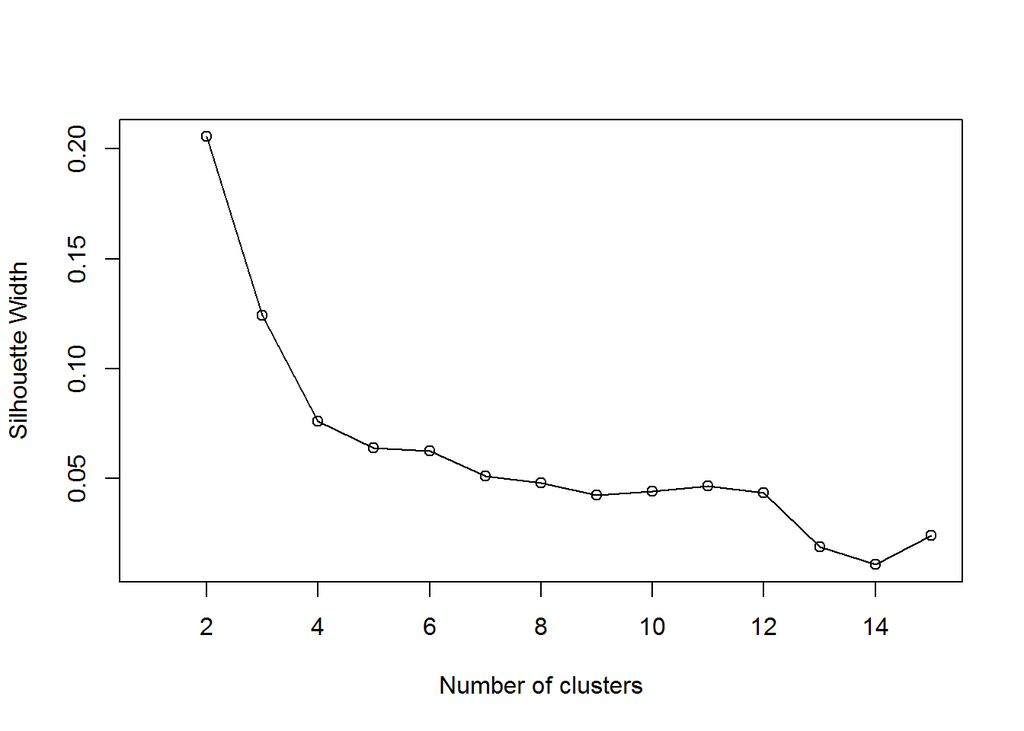

```r
sil_width <- c(NA)
set.seed(0)
for(i in 2:15){

  codsil2 <- pam(coddaisy2,
                 diss = TRUE,
                 k = i)

  sil_width[i] <- codsil2$silinfo$avg.width

}


# Plot sihouette width (higher is better)

plot(1:15, sil_width,
     xlab = "Number of clusters",
     ylab = "Silhouette Width")
lines(1:15, sil_width)
```

As we can see the results aren’t good to begin with. By cluster 5 we’re already at terribly messy clusters. After 12 the width drops to just 0.025. We’ll try just 12 clusters. We’ll try the same sort of analysis we did before with kmodes and see if we can’t get anything more useful out of it.

```r
set.seed(0)
codpam2 <- pam(coddaisy2, k=12)
sort(table(codpam2$clustering),decreasing=T) #The clusters are much more uniform than before, since we have less of them.
```

```
##
##    3    4    2   10    5    7   11    6    9    1    8   12
## 1678 1594 1149  901  845  742  697  558  549  524  441  322
```

```r
sort(table(cc$ICDCode[which(as.numeric(codpam2$clustering)==12)]), decreasing=T)[1:20]
```

```
##
## J449 I251 C349 E149 I219 I48  I250 I64  E785 I119 C259 I110 A419 C80  I10
##   82   15   13    8    8    8    7    7    6    6    5    5    4    4    4
## I429 N185 N390 F019 G309
##    4    4    4    3    3
```

```r
#All our groups happen to have at least 20 different conditions, unlike last time - even the smaller ones.

eee<- trimws(unlist(dimnames(sort(table(cc$ICDCode[which(as.numeric(codpam2$clustering)==3)]),decreasing=T)[1:20])))
fff<- trimws(unlist(dimnames(sort(table(cc$ICDCode[which(as.numeric(codpam2$clustering)==4)]),decreasing=T)[1:20])))
ggg<- trimws(unlist(dimnames(sort(table(cc$ICDCode[which(as.numeric(codpam2$clustering)==2)]),decreasing=T)[1:20])))
hhh<- trimws(unlist(dimnames(sort(table(cc$ICDCode[which(as.numeric(codpam2$clustering)==1)]),decreasing=T)[1:20])))
iii<- trimws(unlist(dimnames(sort(table(cc$ICDCode[which(as.numeric(codpam2$clustering)==8)]),decreasing=T)[1:20])))
jjj<- trimws(unlist(dimnames(sort(table(cc$ICDCode[which(as.numeric(codpam2$clustering)==12)]),decreasing=T)[1:20])))



icd$Description[match(eee, icd$Code)]
```

```
##  [1] Atherosclerotic heart disease
##  [2] Alzheimer disease, unspecified
##  [3] Atherosclerotic cardiovascular disease, so described
##  [4] Malignant neoplasm of prostate
##  [5] Malignant neoplasm: Colon, unspecified
##  [6] Malignant neoplasm: Pancreas, unspecified
##  [7] Congestive heart failure
##  [8] Acute myocardial infarction, unspecified
##  [9] Malignant neoplasm: Bronchus or lung, unspecified
## [10] Unspecified dementia
## [11] Stroke, not specified as haemorrhage or infarction
## [12] Malignant neoplasm: Oesophagus, unspecified
## [13] Parkinson disease
## [14] Sepsis, unspecified
## [15] Malignant neoplasm of kidney, except renal pelvis
## [16] Pneumonia, unspecified
## [17] Malignant neoplasm: Brain, unspecified
## [18] Cardiac arrest, unspecified
## [19] Hypertensive heart disease without (congestive) heart failure
## [20] Cardiomyopathy, unspecified
## 12079 Levels: 4-Aminophenol derivatives ... Zygomycosis, unspecified
```

```r
icd$Description[match(fff, icd$Code)]
```

```
##  [1] Malignant neoplasm: Breast, unspecified
##  [2] Congestive heart failure
##  [3] Stroke, not specified as haemorrhage or infarction
##  [4] Chronic obstructive pulmonary disease, unspecified
##  [5] Malignant neoplasm: Colon, unspecified
##  [6] Alzheimer disease, unspecified
##  [7] Acute myocardial infarction, unspecified
##  [8] Malignant neoplasm: Pancreas, unspecified
##  [9] Malignant neoplasm: Bronchus or lung, unspecified
## [10] Malignant neoplasm of ovary
## [11] Atherosclerotic cardiovascular disease, so described
## [12] Atherosclerotic heart disease
## [13] Pneumonia, unspecified
## [14] Sepsis, unspecified
## [15] Unspecified dementia
## [16] Hypertensive heart disease without (congestive) heart failure
## [17] Cardiac arrest, unspecified
## [18] Malignant neoplasm, without specification of site
## [19] Parkinson disease
## [20] Multiple myeloma
## 12079 Levels: 4-Aminophenol derivatives ... Zygomycosis, unspecified
```

```r
icd$Description[match(ggg, icd$Code)]
```

```
##  [1] Malignant neoplasm: Bronchus or lung, unspecified
##  [2] Atherosclerotic cardiovascular disease, so described
##  [3] Chronic obstructive pulmonary disease, unspecified
##  [4] Acute myocardial infarction, unspecified
##  [5] Malignant neoplasm: Liver cell carcinoma
##  [6] Unspecified diabetes mellitus: Without complications
##  [7] Alcoholic cirrhosis of liver
##  [8] Atherosclerotic heart disease
##  [9] Malignant neoplasm, without specification of site
## [10] Hypertensive heart disease without (congestive) heart failure
## [11] Stroke, not specified as haemorrhage or infarction
## [12] Sepsis, unspecified
## [13] Congestive heart failure
## [14] Chronic viral hepatitis C
## [15] Malignant neoplasm: Colon, unspecified
## [16] Malignant neoplasm of kidney, except renal pelvis
## [17] Malignant neoplasm: Oesophagus, unspecified
## [18] Chronic obstructive pulmonary disease with acute lower respiratory infection
## [19] Emphysema, unspecified
## [20] Malignant neoplasm: Bladder, unspecified
## 12079 Levels: 4-Aminophenol derivatives ... Zygomycosis, unspecified
```

```r
icd$Description[match(hhh, icd$Code)]
```

```
##  [1] Acute myocardial infarction, unspecified
##  [2] Unspecified diabetes mellitus: Without complications
##  [3] Stroke, not specified as haemorrhage or infarction
##  [4] Atherosclerotic cardiovascular disease, so described
##  [5] Unspecified dementia
##  [6] Malignant neoplasm: Pancreas, unspecified
##  [7] Malignant neoplasm of prostate
##  [8] Alzheimer disease, unspecified
##  [9] Hypertensive heart disease without (congestive) heart failure
## [10] Malignant neoplasm of kidney, except renal pelvis
## [11] Atherosclerotic heart disease
## [12] Chronic obstructive pulmonary disease, unspecified
## [13] Unspecified diabetes mellitus: With renal complications
## [14] Hypertensive heart disease with (congestive) heart failure
## [15] Cardiomyopathy, unspecified
## [16] Sepsis, unspecified
## [17] Congestive heart failure
## [18] Intracerebral haemorrhage, unspecified
## [19] Malignant neoplasm: Bronchus or lung, unspecified
## [20] Malignant neoplasm, without specification of site
## 12079 Levels: 4-Aminophenol derivatives ... Zygomycosis, unspecified
```

```r
icd$Description[match(iii, icd$Code)]
```

```
##  [1] Pneumonia, unspecified
##  [2] Acute myocardial infarction, unspecified
##  [3] Urinary tract infection, site not specified
##  [4] Pneumonitis due to food and vomit
##  [5] Vascular disorder of intestine, unspecified
##  [6] Alcoholic cirrhosis of liver
##  [7] Sepsis, unspecified
##  [8] Atrial fibrillation and flutter
##  [9] Malignant neoplasm, without specification of site
## [10] Unspecified diabetes mellitus: Without complications
## [11] Enterocolitis due to Clostridium difficile
## [12] Stroke, not specified as haemorrhage or infarction
## [13] Malignant neoplasm: Bronchus or lung, unspecified
## [14] Multiple sclerosis
## [15] Essential (primary) hypertension
## [16] Congestive heart failure
## [17] Chronic kidney disease, stage 5
## [18] Malignant neoplasm: Stomach, unspecified
## [19] Malignant neoplasm: Pancreas, unspecified
## [20] Malignant neoplasm of ovary
## 12079 Levels: 4-Aminophenol derivatives ... Zygomycosis, unspecified
```

```r
icd$Description[match(jjj, icd$Code)]
```

```
##  [1] Chronic obstructive pulmonary disease, unspecified
##  [2] Atherosclerotic heart disease
##  [3] Malignant neoplasm: Bronchus or lung, unspecified
##  [4] Unspecified diabetes mellitus: Without complications
##  [5] Acute myocardial infarction, unspecified
##  [6] Atrial fibrillation and flutter
##  [7] Atherosclerotic cardiovascular disease, so described
##  [8] Stroke, not specified as haemorrhage or infarction
##  [9] Hyperlipidaemia, unspecified
## [10] Hypertensive heart disease without (congestive) heart failure
## [11] Malignant neoplasm: Pancreas, unspecified
## [12] Hypertensive heart disease with (congestive) heart failure
## [13] Sepsis, unspecified
## [14] Malignant neoplasm, without specification of site
## [15] Essential (primary) hypertension
## [16] Cardiomyopathy, unspecified
## [17] Chronic kidney disease, stage 5
## [18] Urinary tract infection, site not specified
## [19] Vascular dementia, unspecified
## [20] Alzheimer disease, unspecified
## 12079 Levels: 4-Aminophenol derivatives ... Zygomycosis, unspecified
```

Just like before we’ve got a lot of common conditions present across the board. We’ll try again to look at what’s unique in these clusters. We can also take a look at our medoids to get a clue as to what each cluster looks like.

```r
cc[codpam2$medoids,c(2,5,7,15,18,24)]
```

```
##         Education2003 AgeDetail MaritalStatus ICDCode CauseRecode39
## 430698              3        73             M    I219            21
## 433641              3        64             M    C349             8
## 1682188             1        77             M    I251            21
## 70311               4        79             S    C509             9
## 467872              1        89             D    F03             37
## 616485              3        86             W    I251            21
## 1695992             3        68             D    C349             8
## 649565              3        55             M    J189            27
## 144028              3        83             M    J189            27
## 204922              4        85             W    J449            28
## 1807539             5        93             W    G309            17
## 436673              3        71             M    J449            28
##         RaceRecord5
## 430698            w
## 433641            w
## 1682188           w
## 70311             w
## 467872            w
## 616485            w
## 1695992           w
## 649565            w
## 144028            w
## 204922            w
## 1807539           w
## 436673            w
```

```r
b[codpam2$medoids,]
```

```
##         rac1 rac2 rac3 rac4 rac5 rac6 rac7 Sex AgeDetail
## 430698  I219 E149  I10                       M        73
## 433641  C349 F179                            M        64
## 1682188 I251                                 M        77
## 70311   C509                                 F        79
## 467872   F03 I469                            F        89
## 616485  I251  F03  I10                       F        86
## 1695992 C349 F179                            F        68
## 649565  J189 A419 I469                       F        55
## 144028  J189 A419 I469                       M        83
## 204922  J449 I469                            M        85
## 1807539 G309  I10                            F        93
## 436673  J449 E149 F179  I10                  F        71
```

```r
#I can't really tell much from these to be honest.

icdeee <- as.character(icd$Description[match(eee, icd$Code)])
icdfff <- as.character(icd$Description[match(fff, icd$Code)])
icdggg <- as.character(icd$Description[match(ggg, icd$Code)])

icdhhh <- as.character(icd$Description[match(hhh, icd$Code)])
icdiii <- as.character(icd$Description[match(iii, icd$Code)])
icdjjj <- as.character(icd$Description[match(jjj, icd$Code)])


icdeee[-which(icdeee %in% c(icdfff,icdggg))]
```

```
## [1] "Malignant neoplasm of prostate"
## [2] "Malignant neoplasm: Brain, unspecified"
## [3] "Cardiomyopathy, unspecified"
```

```r
icdfff[-which(icdfff %in% c(icdeee,icdggg))]
```

```
## [1] "Malignant neoplasm: Breast, unspecified"
## [2] "Malignant neoplasm of ovary"
## [3] "Multiple myeloma"
```

```r
icdggg[-which(icdggg %in% c(icdeee,icdfff))]
```

```
## [1] "Malignant neoplasm: Liver cell carcinoma"
## [2] "Unspecified diabetes mellitus: Without complications"
## [3] "Alcoholic cirrhosis of liver"
## [4] "Chronic viral hepatitis C"
## [5] "Chronic obstructive pulmonary disease with acute lower respiratory infection"
## [6] "Emphysema, unspecified"
## [7] "Malignant neoplasm: Bladder, unspecified"
```

```r
#We can try with more clusters this time, but our trick of only taking unique values would backfire if we added more, since there would be more overlap.

icdhhh[-which(icdhhh %in% c(icdiii,icdjjj))]
```

```
## [1] "Unspecified dementia"
## [2] "Malignant neoplasm of prostate"
## [3] "Malignant neoplasm of kidney, except renal pelvis"
## [4] "Unspecified diabetes mellitus: With renal complications"
## [5] "Intracerebral haemorrhage, unspecified"
```

```r
icdiii[-which(icdiii %in% c(icdhhh,icdjjj))]
```

```
## [1] "Pneumonia, unspecified"
## [2] "Pneumonitis due to food and vomit"
## [3] "Vascular disorder of intestine, unspecified"
## [4] "Alcoholic cirrhosis of liver"
## [5] "Enterocolitis due to Clostridium difficile"
## [6] "Multiple sclerosis"
## [7] "Malignant neoplasm: Stomach, unspecified"
## [8] "Malignant neoplasm of ovary"
```

```r
icdjjj[-which(icdjjj %in% c(icdhhh,icdiii))]
```

```
## [1] "Hyperlipidaemia, unspecified"   "Vascular dementia, unspecified"
```

Cluster 1 has Prostate Cancer, Brain Cancer, and Cardiomyopathy a hardening or thickening of the muscle. Cluster 2 has Breast and Ovary, and White Blood Cell Cancer. Cluster 3 has Liver diseases, COPD, Emphysema, Bladder Cancer, and Diabetes.

Cluster 4 has Dementia, Prostate and Kidney Cancer, Diabetes and Brain Haemorrage Cluster 5 has Pneumonia, Cirrhosis, Intestinal Inflammation, Stomach and Ovary Cancer, and MS Cluster 6 has High Colesterol and Poor Brain Bloodflow

Once again, while very sensible there is nothing here that’s all that shocking. It is cool at least that including sex as a variable gave us clusters for man cancer and lady cancer.

# Question 3:

Does there exist a stronger relationship between accident and self-harm victims than between each and the general population?

For this analysis we’ll turn back to the mort15accidental dataset we put aside earlier. The first order of business will be ask which are accidental deaths and which have to do with self-harm. $MannerOfDeath has the answer for us:

1 … Accident 2 … Suicide 3 … Homicide 4 … Pending investigation 5 … Could not determine 6 … Self-Inflicted 7 … Natural - Remember these were listed under CauseRecode358 as not being medically related deaths.

```r
table(mort15accidental$MannerOfDeath)
```

```
##
##      1      2      3      4      5      7
## 124075  40212  16124   3037   7261  11293
```

```r
#3 is useless to us, 6 is empty, and 4 and 5 have too much uncertainty. We'll take a look at what kinds of deaths 7 has to see whether we should include them.

sort(table(mort15accidental$CauseRecode358[which(mort15accidental$MannerOfDeath == 7)]), decreasing=T)
```

```
##
##  423  410  456  406  420  421  454  404  397  455  402  407  405  414  411
## 3856 2672 1457 1117  783  580  246  225  114   36   35   35   28   25   20
##  393  409  422  388  386  440  387  392  395  399  384  396  408  425  426
##   13   12   12    5    4    3    2    2    2    2    1    1    1    1    1
##  429  452
##    1    1
```

```r
table(mort15accidental[which(mort15accidental$CauseRecode358==420),c(4,7)])
```

```
##    MaritalStatus
## Sex     D     M     S     U     W
##   F  3778  3656  4567    87   898
##   M  5625  4760 14108   150   514
```

Among those listed as ‘natural’ are:

423 Unspecified Accidents (Which the ICD says could include work accidents - falling debris etc.) 410 Choking 456 Complications Following Medical Care 406 Falls 420-421 Accidental Poisonings

While it’s possible some of these could be better described as accidents or suicides, none of them are demanding to be treated that way. We’ll just have to just trust the investigators that these were more like acts of god, and ignore them in our analysis.

```r
mort15suicide <- mort15accidental[which(mort15accidental$MannerOfDeath == 2),]
mort15accidental <- mort15accidental[which(mort15accidental$MannerOfDeath == 1),]
#Let's start with some basic fact finding just like before.
#We'll check education, month and day of death, sex, age, marital status, method of disposition, and race
c(apply(mort15suicide[,c(2,3,4,7,8,11,24)],2,table),mean(mort15suicide$AgeDetail),median(mort15suicide$AgeDetail))
```

```
## $Education2003
##
##     1     2     3     4     5     6     7     8
##  1233  4125 16601  7299  3194  5183  1728   849
##
## $MonthOfDeath
##
##    1    2    3    4    5    6    7    8    9   10   11   12
## 3295 2956 3612 3407 3618 3483 3650 3558 3225 3309 2976 3123
##
## $Sex
##
##     F     M
##  9056 31156
##
## $MaritalStatus
##
##     D     M     S     U     W
##  9047 14465 13922   150  2628
##
## $DayOfWeekofDeath
##
##    1    2    3    4    5    6    7    9
## 5631 6253 6163 5728 5746 5568 5103   20
##
## $MethodOfDisposition
##
##     B     C     D     E     O     R     U
## 10845 27740   197   176   112  1125    17
##
## $RaceRecord5
##
##     1     2     3     4
## 36267  2206   518  1221
##
## [[8]]
## [1] 48.02915
##
## [[9]]
## [1] 48
```

```r
c(apply(mort15accidental[,c(2,3,4,7,8,11,24)],2,table),mean(mort15accidental$AgeDetail),median(mort15accidental$AgeDetail))
```

```
## $Education2003
##
##     1     2     3     4     5     6     7     8
##  8026 16155 55807 19073  8192 11302  3856  1664
##
## $MonthOfDeath
##
##     1     2     3     4     5     6     7     8     9    10    11    12
## 10518  9397 10237  9732 10582 10406 11009 10758 10370 10697 10035 10334
##
## $Sex
##
##     F     M
## 44343 79732
##
## $MaritalStatus
##
##     D     M     S     U     W
## 23516 38572 40870   537 20580
##
## $DayOfWeekofDeath
##
##     1     2     3     4     5     6     7     9
## 18851 16773 16604 16714 17400 18136 19581    16
##
## $MethodOfDisposition
##
##     B     C     D     E     O     R     U
## 47974 68774   575  1089   416  5187    60
##
## $RaceRecord5
##
##      1      2      3      4
## 106835  12817   1764   2659
##
## [[8]]
## [1] 55.31278
##
## [[9]]
## [1] 53
```

In general both groups die young, are overwhelmingly male, and moderately educated. Suicides are disproportionately smaller among widows (Maybe because widows are mostly formerly married women, as we saw earlier). For more precise analysis we’ll use a Multinomial Logistic Regression model to compare people with accidental, suicidal, and natural deaths. Multinom, included in the nnet package takes a reference level of a categorical variable and gives coefficients for logit probabilities from the input variables.

```r
mort15[,28]<- NULL
mort15accidental[,28]<-rep(3, times=length(mort15accidental$V44))
levels(mort15accidental$RaceRecord5) <- c("w","b","n","p")
mort15suicide[,28]<-rep(2, times=length(mort15suicide$V44))
levels(mort15suicide$RaceRecord5) <- c("w","b","n","p")
mort15[,28]<-rep(1, times=length(mort15$V44))
mort15multinom <- rbind.data.frame(mort15, mort15suicide, mort15accidental)
mort15multinom[,28]<- as.factor(mort15multinom[,28])
#install.packages("nnet")
library(nnet)
mort15multinom$V28 <- relevel(mort15multinom$V28, ref="1")
model <- multinom(V28 ~ AgeDetail + Sex + Education2003 + MethodOfDisposition + RaceRecord5 + MaritalStatus, data=mort15multinom)
summary(model)
```

```
## Call:
## multinom(formula = V28 ~ AgeDetail + Sex + Education2003 + MethodOfDisposition +
##     RaceRecord5 + MaritalStatus, data = mort15multinom)
##
## Coefficients:
##   (Intercept)   AgeDetail      SexM Education20032 Education20033
## 2   0.6828633 -0.09491180 0.9221121      0.3287606      0.5207542
## 3   1.3717050 -0.06904945 0.3623862      0.1451447      0.1520243
##   Education20034 Education20035 Education20036 Education20037
## 2      0.7168683      0.7600518     0.94339147      1.0334594
## 3      0.1648289      0.1148496     0.09626538      0.1086933
##   Education20038 MethodOfDispositionC MethodOfDispositionD
## 2      1.2705069           0.54797187           -0.1845664
## 3      0.2533929           0.06983047           -0.6362310
##   MethodOfDispositionE MethodOfDispositionO MethodOfDispositionR
## 2          -0.14492560            0.2468188            0.1559282
## 3           0.07343572            0.1424657            0.3633274
##   MethodOfDispositionU RaceRecord5b RaceRecord5n RaceRecord5p
## 2            1.0301728   -1.2229939  -0.05873368   -0.1684172
## 3            0.7731192   -0.6496715   0.02709109   -0.3221417
##   MaritalStatusM MaritalStatusS MaritalStatusU MaritalStatusW
## 2     -0.2459749     -0.3488482    -0.22332114     0.02937488
## 3     -0.2327311      0.1834815     0.08990943     0.38779820
##
## Std. Errors:
##   (Intercept)    AgeDetail        SexM Education20032 Education20033
## 2  0.04007842 0.0003850403 0.012698220     0.03383163     0.03059326
## 3  0.02052510 0.0002188057 0.006691143     0.01496625     0.01291934
##   Education20034 Education20035 Education20036 Education20037
## 2     0.03213837     0.03504274     0.03297248     0.03884755
## 3     0.01460497     0.01709414     0.01574071     0.02080154
##   Education20038 MethodOfDispositionC MethodOfDispositionD
## 2     0.04672328           0.01220740           0.07345521
## 3     0.02851352           0.00670523           0.04344312
##   MethodOfDispositionE MethodOfDispositionO MethodOfDispositionR
## 2           0.08007120           0.10282901           0.03353930
## 3           0.03269293           0.05373654           0.01691048
##   MethodOfDispositionU RaceRecord5b RaceRecord5n RaceRecord5p
## 2            0.2598488   0.02293447   0.04783961   0.03179368
## 3            0.1533997   0.01048844   0.02811785   0.02159077
##   MaritalStatusM MaritalStatusS MaritalStatusU MaritalStatusW
## 2    0.014213598    0.016264864     0.08595846     0.02388683
## 3    0.008898068    0.009878793     0.04801915     0.01107093
##
## Residual Deviance: 1095482
## AIC: 1095574
```

From the results page we can get a rough idea of the kinds of effect each variable gives to likelyhood of committing suicide or dying in an accident. For the most part most of the statistics lined up quite nicely between each group. However we can see some interesting differences. Namely: Very well educated people are far more likely to commit suicide, blacks are very unlikely to commit suicide, and we can also see the very clear effect of age on both populations. We can evaluate the accuracy of this model by looking at the pvalues of the coefficients, and the confusion matrix.

```r
dd <- table(predict(model, mort15multinom[,c(2,4,5,7,11,24,28)]), mort15multinom[,28])
dd
```

```
##
##           1       2       3
##   1 2224559   33890  108544
##   2     259     432     557
##   3    6278    5890   14974
```

```r
1-sum(diag(dd))/sum(dd)
```

```
## [1] 0.06488232
```

```r
z <- summary(model)$coefficients/summary(model)$standard.errors
z
```

```
##   (Intercept) AgeDetail     SexM Education20032 Education20033
## 2    17.03818 -246.4984 72.61743       9.717552       17.02186
## 3    66.83063 -315.5743 54.15910       9.698132       11.76719
##   Education20034 Education20035 Education20036 Education20037
## 2       22.30569      21.689276      28.611481      26.602949
## 3       11.28581       6.718657       6.115696       5.225252
##   Education20038 MethodOfDispositionC MethodOfDispositionD
## 2      27.192159             44.88851            -2.512638
## 3       8.886762             10.41433           -14.645149
##   MethodOfDispositionE MethodOfDispositionO MethodOfDispositionR
## 2            -1.809959             2.400284              4.64912
## 3             2.246226             2.651189             21.48534
##   MethodOfDispositionU RaceRecord5b RaceRecord5n RaceRecord5p
## 2             3.964509    -53.32559   -1.2277207    -5.297192
## 3             5.039900    -61.94166    0.9634835   -14.920344
##   MaritalStatusM MaritalStatusS MaritalStatusU MaritalStatusW
## 2      -17.30560      -21.44796      -2.598012       1.229752
## 3      -26.15523       18.57328       1.872366      35.028510
```

```r
p <- (1 - pnorm(abs(z),0,1))*2
p
```

```
##   (Intercept) AgeDetail SexM Education20032 Education20033 Education20034
## 2           0         0    0              0              0              0
## 3           0         0    0              0              0              0
##   Education20035 Education20036 Education20037 Education20038
## 2   0.000000e+00   0.000000e+00   0.000000e+00              0
## 3   1.834066e-11   9.613641e-10   1.739183e-07              0
##   MethodOfDispositionC MethodOfDispositionD MethodOfDispositionE
## 2                    0           0.01198322           0.07030215
## 3                    0           0.00000000           0.02468952
##   MethodOfDispositionO MethodOfDispositionR MethodOfDispositionU
## 2          0.016382350         3.333545e-06         7.354714e-05
## 3          0.008020886         0.000000e+00         4.657760e-07
##   RaceRecord5b RaceRecord5n RaceRecord5p MaritalStatusM MaritalStatusS
## 2            0    0.2195518 1.175968e-07              0              0
## 3            0    0.3353049 0.000000e+00              0              0
##   MaritalStatusU MaritalStatusW
## 2    0.009376516      0.2187899
## 3    0.061155985      0.0000000
```

The model was fairly accurate, but only because suicides and accidental deaths were so rare compared to everything else. Fancier techniques like random forest could probably give a better model. For the most part the variables had good p scores, with exceptions such as widows.